# Untitled

Cheng Gao

3/17/2019

```r
wd<- "/Users/chengg/Google Drive/EPICON/Mycobiome/Fungal ITS/statistic/Total.fungi"
setwd(wd)
library(ggplot2)
library(nlme)
library(MuMIn)
```

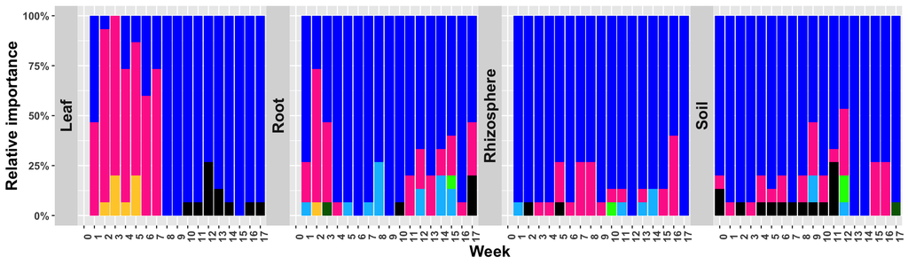

```r
rm(list = ls())
load("EPICON.data.preparation.RC.bNTI.ghost.2019.03.17.Rdata")
col11<-c("#0000FF","#FF3399","#FFCC33","#ff00ff","#00ff00", "deepskyblue", "bisque",   "darkgreen","black", "maroon3",   "grey")
# bNTI.ghost2RC95pct.ghost
bNTI.ghost.RC.part.TP.TREAT$Treatment<-factor(bNTI.ghost.RC.part.TP.TREAT$Treatment, levels= c("Control", "Pre_flowering_drought", "Post_flowering_drought"), labels = c("CON", "PRE", "POST"))
bNTI.ghost.RC.part.TP.TREAT$Habitat<-factor(bNTI.ghost.RC.part.TP.TREAT$Habitat, levels= c("Leaf", "Root", "Rhizosphere", "Soil"), labels = c("Leaf", "Root", "Rhizosphere", "Soil"))
bNTI.ghost.RC.part.TP.TREAT$bNTI.ghost.RC.partition<-factor(bNTI.ghost.RC.part.TP.TREAT$bNTI.ghost.RC.partition,
                                                            labels = c("(-2, 2)   & [-1, -0.95]", "(-2, 2)   & (-0.95, 0.95)",  "(-2, 2)   & [0.95, 1]",   "[2, +∞)  & [0.95, 1]",  "[2, +∞)  & (-0.95, 0.95)"  ,  "[2, +∞)  & [-1, -0.95]" ,  "(-∞, -2] & [0.95, 1]" ,  "(-∞, -2] & (-0.95, 0.95)", "(-∞, -2] & [-1, -0.95]"))

ggplot(bNTI.ghost.RC.part.TP.TREAT[bNTI.ghost.RC.part.TP.TREAT$Treatment=="CON",], aes(x = factor(TP), y = Value ,fill=bNTI.ghost.RC.partition)) +
  geom_bar(stat='identity', position = "fill")+  ###add <   > for relative abundance
  labs(x="Week",y = "Relative importance")+
  facet_wrap(~Habitat, ncol = 4,strip.position= 'left')+
  theme(strip.text = element_text(size = 15,face="bold"),
        panel.spacing = unit(0, "lines"),
        legend.title = element_text(colour="black", size=15, face="bold"),
        legend.text = element_text(colour="black", size=15, face="bold"),
        axis.text=element_text(size=10,face="bold"),
        axis.text.x=element_text(angle = 90),
        axis.title=element_text(size=15,face="bold"))+
  scale_y_continuous(labels = scales::percent)+
  scale_fill_manual(values= col11) + guides(fill=FALSE)
```

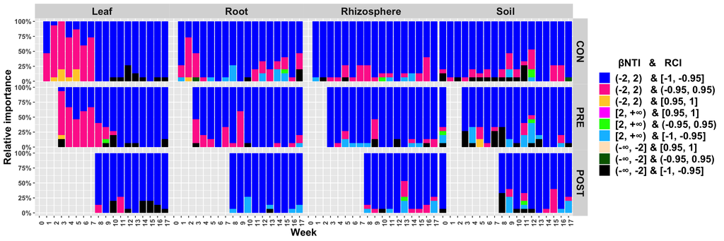

```r
#
rm(list = ls())
load("EPICON.data.preparation.RC.bNTI.ghost.2019.03.17.Rdata")
col11<-c("#0000FF","#FF3399","#FFCC33","#ff00ff","#00ff00", "deepskyblue", "bisque",   "darkgreen","black", "maroon3",   "grey")
# bNTI.ghost2RC95pct.ghost
bNTI.ghost.RC.part.TP.TREAT$Treatment<-factor(bNTI.ghost.RC.part.TP.TREAT$Treatment, levels= c("Control", "Pre_flowering_drought", "Post_flowering_drought"), labels = c("CON", "PRE", "POST"))
bNTI.ghost.RC.part.TP.TREAT$Habitat<-factor(bNTI.ghost.RC.part.TP.TREAT$Habitat, levels= c("Leaf", "Root", "Rhizosphere", "Soil"), labels = c("Leaf", "Root", "Rhizosphere", "Soil"))
bNTI.ghost.RC.part.TP.TREAT$bNTI.ghost.RC.partition<-factor(bNTI.ghost.RC.part.TP.TREAT$bNTI.ghost.RC.partition,
                                                            labels = c("(-2, 2)   & [-1, -0.95]", "(-2, 2)   & (-0.95, 0.95)",  "(-2, 2)   & [0.95, 1]",   "[2, +∞)  & [0.95, 1]",  "[2, +∞)  & (-0.95, 0.95)"  ,  "[2, +∞)  & [-1, -0.95]" ,  "(-∞, -2] & [0.95, 1]" ,  "(-∞, -2] & (-0.95, 0.95)", "(-∞, -2] & [-1, -0.95]"))
ggplot(bNTI.ghost.RC.part.TP.TREAT, aes(x = factor(TP), y = Value ,fill=bNTI.ghost.RC.partition)) +
  geom_bar(stat='identity', position = "fill")+  ###add <   > for relative abundance
  labs(x="Week",y = "Relative importance")+
  facet_grid(Treatment~Habitat)+
  labs(fill="       βNTI   &   RCI")+
  theme(strip.text = element_text(size = 15,face="bold"),
        panel.spacing = unit(0, "lines"),
        legend.title = element_text(colour="black", size=15, face="bold"),
        legend.text = element_text(colour="black", size=15, face="bold"),
        axis.text=element_text(size=10,face="bold"),
        axis.text.x=element_text(angle = 90),
        axis.title=element_text(size=15,face="bold"))+
  scale_y_continuous(labels = scales::percent)+
  scale_fill_manual(values= col11)
```

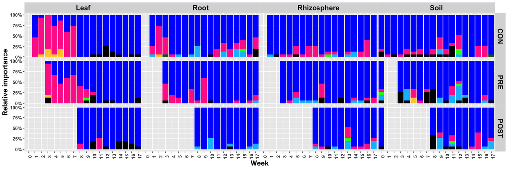

```r
ggplot(bNTI.ghost.RC.part.TP.TREAT, aes(x = factor(TP), y = Value ,fill=bNTI.ghost.RC.partition)) +
  geom_bar(stat='identity', position = "fill")+  ###add <   > for relative abundance
  labs(x="Week",y = "Relative importance")+
 facet_grid(Treatment~Habitat)+
  theme(strip.text = element_text(size = 15,face="bold"),
        panel.spacing = unit(0, "lines"),
        legend.title = element_text(colour="black", size=15, face="bold"),
        legend.text = element_text(colour="black", size=15, face="bold"),
        axis.text=element_text(size=10,face="bold"),
        axis.text.x=element_text(angle = 90),
        axis.title=element_text(size=15,face="bold"))+
  scale_y_continuous(labels = scales::percent)+
  scale_fill_manual(values= col11) + guides(fill=FALSE)
```

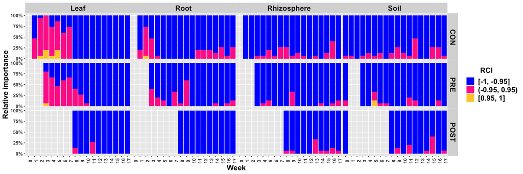

```r
######RCI alone
rm(list = ls())
load("EPICON.data.preparation.RC.bNTI.ghost.2019.03.17.Rdata")
col11<-c("#0000FF","#FF3399","#FFCC33","#ff00ff","#00ff00", "deepskyblue", "bisque",   "darkgreen","black", "maroon3",   "grey")

RC.part.TP.TREAT$Treatment<-factor(RC.part.TP.TREAT$Treatment, levels= c("Control", "Pre_flowering_drought", "Post_flowering_drought"), labels = c("CON", "PRE", "POST"))
RC.part.TP.TREAT$Habitat<-factor(RC.part.TP.TREAT$Habitat, levels= c("Leaf", "Root", "Rhizosphere", "Soil"), labels = c("Leaf", "Root", "Rhizosphere", "Soil"))
RC.part.TP.TREAT$RC.partition<-factor(RC.part.TP.TREAT$RC.partition,
                                      labels = c("[-1, -0.95]", "(-0.95, 0.95)", "[0.95, 1]"))

ggplot(RC.part.TP.TREAT, aes(x = factor(TP), y = Value ,fill=RC.partition)) +
  geom_bar(stat='identity', position = "fill")+  ###add <   > for relative abundance
  labs(x="Week",y = "Relative importance")+
 facet_grid(Treatment~Habitat)+
  labs(fill="       RCI")+
  theme(strip.text = element_text(size = 15,face="bold"),
        panel.spacing = unit(0, "lines"),
        legend.title = element_text(colour="black", size=15, face="bold"),
        legend.text = element_text(colour="black", size=15, face="bold"),
        axis.text=element_text(size=10,face="bold"),
        axis.text.x=element_text(angle = 90),
        axis.title=element_text(size=15,face="bold"))+
  scale_y_continuous(labels = scales::percent)+
  scale_fill_manual(values= col11)
```

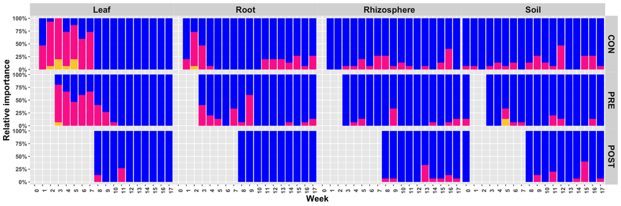

```r
ggplot(RC.part.TP.TREAT, aes(x = factor(TP), y = Value ,fill=RC.partition)) +
  geom_bar(stat='identity', position = "fill")+  ###add <   > for relative abundance
  labs(x="Week",y = "Relative importance")+
 facet_grid(Treatment~Habitat)+
  theme(strip.text = element_text(size = 15,face="bold"),
        panel.spacing = unit(0, "lines"),
        legend.title = element_text(colour="black", size=15, face="bold"),
        legend.text = element_text(colour="black", size=15, face="bold"),
        axis.text=element_text(size=10,face="bold"),
        axis.text.x=element_text(angle = 90),
        axis.title=element_text(size=15,face="bold"))+
  scale_y_continuous(labels = scales::percent)+
  scale_fill_manual(values= col11) + guides(fill=FALSE)
```

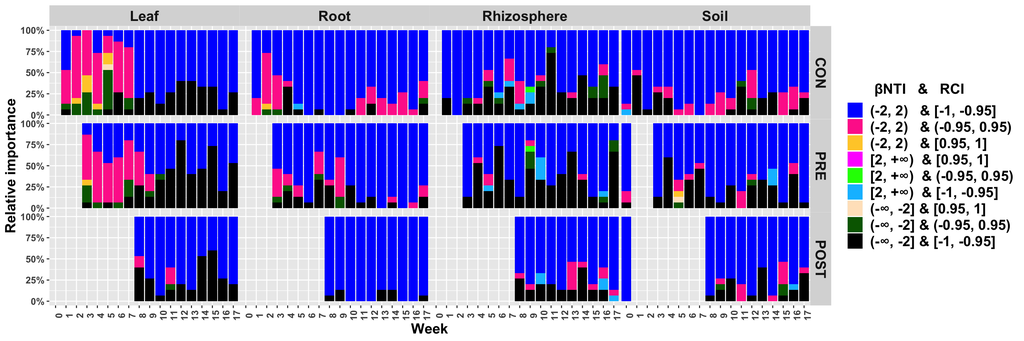

```r
#####
rm(list = ls())
load("EPICON.data.preparation.RC.bNTI.its2.2019.03.17.Rdata")
col11<-c("#0000FF","#FF3399","#FFCC33","#ff00ff","#00ff00","deepskyblue", "bisque",   "darkgreen","black", "maroon3",   "grey")
# bNTI.its22RC95pct
bNTI.its2.RC.part.TP.TREAT$Treatment<-factor(bNTI.its2.RC.part.TP.TREAT$Treatment, levels= c("Control", "Pre_flowering_drought", "Post_flowering_drought"), labels = c("CON", "PRE", "POST"))
bNTI.its2.RC.part.TP.TREAT$Habitat<-factor(bNTI.its2.RC.part.TP.TREAT$Habitat, levels= c("Leaf", "Root", "Rhizosphere", "Soil"), labels = c("Leaf", "Root", "Rhizosphere", "Soil"))
bNTI.its2.RC.part.TP.TREAT$bNTI.its2.RC.partition<-factor(bNTI.its2.RC.part.TP.TREAT$bNTI.its2.RC.partition,
                                                            labels = c("(-2, 2)   & [-1, -0.95]", "(-2, 2)   & (-0.95, 0.95)",  "(-2, 2)   & [0.95, 1]",   "[2, +∞)  & [0.95, 1]",  "[2, +∞)  & (-0.95, 0.95)"  ,  "[2, +∞)  & [-1, -0.95]" ,  "(-∞, -2] & [0.95, 1]" ,  "(-∞, -2] & (-0.95, 0.95)", "(-∞, -2] & [-1, -0.95]"))
ggplot(bNTI.its2.RC.part.TP.TREAT, aes(x = factor(TP), y = Value ,fill=bNTI.its2.RC.partition)) +
  geom_bar(stat='identity', position = "fill")+  ###add <   > for relative abundance
  labs(x="Week",y = "Relative importance")+
 facet_grid(Treatment~Habitat)+
  labs(fill="       βNTI   &   RCI")+
  theme(strip.text = element_text(size = 15,face="bold"),
        panel.spacing = unit(0, "lines"),
        legend.title = element_text(colour="black", size=15, face="bold"),
        legend.text = element_text(colour="black", size=15, face="bold"),
        axis.text=element_text(size=10,face="bold"),
        axis.text.x=element_text(angle = 90),
        axis.title=element_text(size=15,face="bold"))+
  scale_y_continuous(labels = scales::percent)+
  scale_fill_manual(values= col11)
```

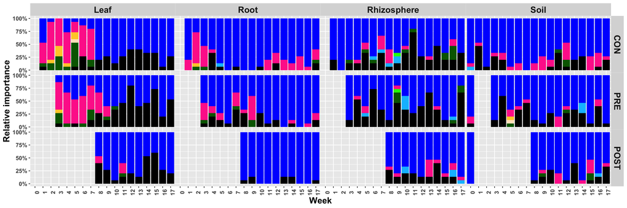

```r
ggplot(bNTI.its2.RC.part.TP.TREAT, aes(x = factor(TP), y = Value ,fill=bNTI.its2.RC.partition)) +
  geom_bar(stat='identity', position = "fill")+  ###add <   > for relative abundance
  labs(x="Week",y = "Relative importance")+
 facet_grid(Treatment~Habitat)+
  theme(strip.text = element_text(size = 15,face="bold"),
        panel.spacing = unit(0, "lines"),
        legend.title = element_text(colour="black", size=15, face="bold"),
        legend.text = element_text(colour="black", size=15, face="bold"),
        axis.text=element_text(size=10,face="bold"),
        axis.text.x=element_text(angle = 90),
        axis.title=element_text(size=15,face="bold"))+
  scale_y_continuous(labels = scales::percent)+
  scale_fill_manual(values= col11) + guides(fill=FALSE)
```

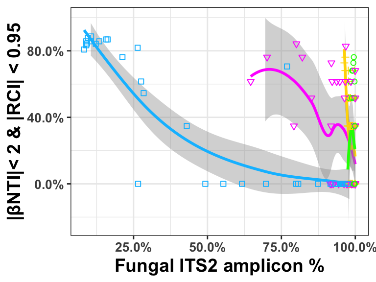

```r
##### RC.bNTI.ghost

rm(list = ls())
load("EPICON.data.preparation.RC.bNTI.ghost.2019.03.17.Rdata")
Lagg$Habitat<-factor(Lagg$Habitat, levels = c("Leaf", "Root", "Rhizosphere", "Soil"))
ggplot(data=Lagg, aes(y=bNTI.ghost2RC95pct, x= Fungi.pct/100, color=Habitat, shape =Habitat))+
  geom_smooth( method="loess", span=0.9)+ geom_point() + theme_bw()+
  xlab("Fungal ITS2 amplicon %")+ylab("|βNTI|< 2 & |RCI| < 0.95")+
  scale_color_manual(values = c("deepskyblue","#ff00ff", "gold", "#00ff00"))+ scale_shape_manual(values=c(0, 6, 3, 1))+
  scale_y_continuous(labels = scales::percent, limits = c(-0.25, 1))+
  scale_x_continuous(labels = scales::percent)+
  theme(axis.text=element_text(size=10,face="bold"),
        axis.title=element_text(size=14,face="bold"))+ theme(legend.position = "none")
```

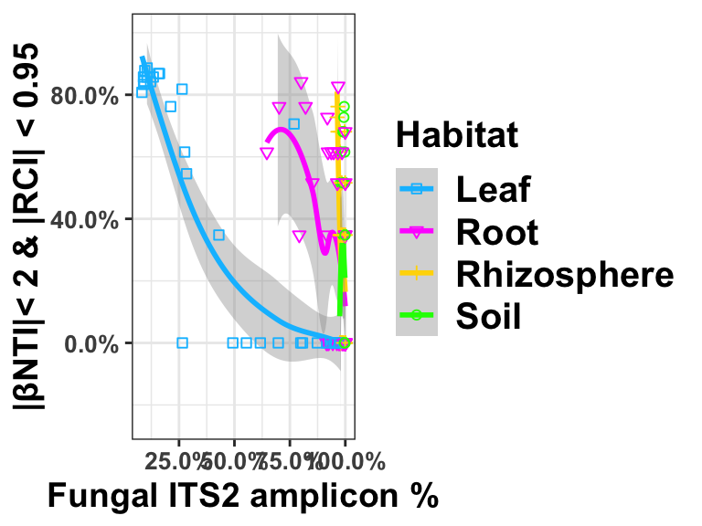

```r
ggplot(data=Lagg, aes(y=bNTI.ghost2RC95pct, x= Fungi.pct/100, color=Habitat, shape =Habitat))+
  geom_smooth( method="loess", span=0.9)+ geom_point() + theme_bw()+
  xlab("Fungal ITS2 amplicon %")+ylab("|βNTI|< 2 & |RCI| < 0.95")+
  scale_color_manual(values = c("deepskyblue","#ff00ff", "gold", "#00ff00"))+ scale_shape_manual(values=c(0, 6, 3, 1))+
  scale_y_continuous(labels = scales::percent, limits = c(-0.25, 1))+
  scale_x_continuous(labels = scales::percent)+
  theme(axis.text=element_text(size=10,face="bold"),
        axis.title=element_text(size=14,face="bold"),
        legend.title = element_text(colour="black", size=15, face="bold"),
        legend.text = element_text(colour="black", size=15, face="bold"))
```

```r
lme0<-lme(bNTI.ghost2RC95pct~Fungi.pct,random=~1|Habitat,data=Lagg)
summary(lme0)
```

```
## Linear mixed-effects model fit by REML
##  Data: Lagg
##        AIC      BIC    logLik
##   42.45271 54.97231 -17.22636
##
## Random effects:
##  Formula: ~1 | Habitat
##         (Intercept)  Residual
## StdDev:     0.16558 0.2487368
##
## Fixed effects: bNTI.ghost2RC95pct ~ Fungi.pct
##                  Value  Std.Error  DF   t-value p-value
## (Intercept)  1.1427038 0.12281861 166  9.303996       0
## Fungi.pct   -0.0097883 0.00101027 166 -9.688855       0
##  Correlation:
##           (Intr)
## Fungi.pct -0.722
##
## Standardized Within-Group Residuals:
##        Min         Q1        Med         Q3        Max
## -2.5896032 -1.0192690  0.1305237  0.5063274  2.3209699
##
## Number of Observations: 171
## Number of Groups: 4
```

```r
anova(lme0)
```

```
##             numDF denDF  F-value p-value
## (Intercept)     1   166 11.12029  0.0011
## Fungi.pct       1   166 93.87391  <.0001
```

```r
r.squaredGLMM(lme0)
```

```
##            R2m       R2c
## [1,] 0.4004778 0.5845694
```

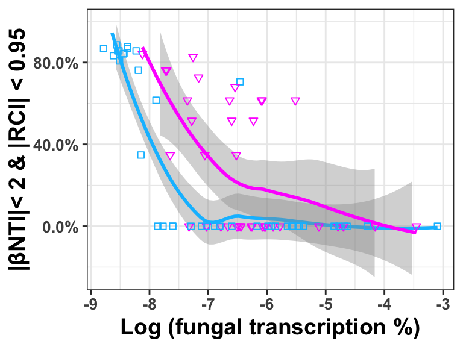

```r
Traagg$Habitat<-factor(Traagg$Habitat, levels = c("Leaf", "Root", "Rhizosphere", "Soil"))
ggplot(data=Traagg, aes(y=bNTI.ghost2RC95pct, x= log(Fungi.pct.tra) , color=Habitat, shape =Habitat) )+
  geom_smooth( method="loess", span=0.9)+ geom_point() + theme_bw()+
  xlab("Log (fungal transcription %)")+ylab("|βNTI|< 2 & |RCI| < 0.95")+
  scale_y_continuous(labels = scales::percent, limits = c(-0.25, 1))+
  scale_color_manual(values = c("deepskyblue","#ff00ff", "gold", "#00ff00"))+ scale_shape_manual(values=c(0, 6, 3, 1))+
  theme(axis.text=element_text(size=10,face="bold"),
        axis.title=element_text(size=14,face="bold"))+ theme(legend.position = "none")
```

```r
lme0<-lme(bNTI.ghost2RC95pct~log(Fungi.pct.tra),random=~1|Habitat,data=Traagg)
summary(lme0)
```

```
## Linear mixed-effects model fit by REML
##  Data: Traagg
##        AIC      BIC    logLik
##   36.01427 45.28422 -14.00713
##
## Random effects:
##  Formula: ~1 | Habitat
##         (Intercept)  Residual
## StdDev:  0.02576222 0.2737831
##
## Fixed effects: bNTI.ghost2RC95pct ~ log(Fungi.pct.tra)
##                         Value  Std.Error DF   t-value p-value
## (Intercept)        -0.9219422 0.16453287 74 -5.603392       0
## log(Fungi.pct.tra) -0.1824729 0.02422892 74 -7.531201       0
##  Correlation:
##                    (Intr)
## log(Fungi.pct.tra) 0.976
##
## Standardized Within-Group Residuals:
##        Min         Q1        Med         Q3        Max
## -1.8381389 -0.8342959  0.1419786  0.8515747  1.9052812
##
## Number of Observations: 77
## Number of Groups: 2
```

```r
anova(lme0)
```

```
##                    numDF denDF  F-value p-value
## (Intercept)            1    74 63.05629  <.0001
## log(Fungi.pct.tra)     1    74 56.71899  <.0001
```

```r
r.squaredGLMM(lme0)
```

```
##            R2m       R2c
## [1,] 0.4274445 0.4324695
```

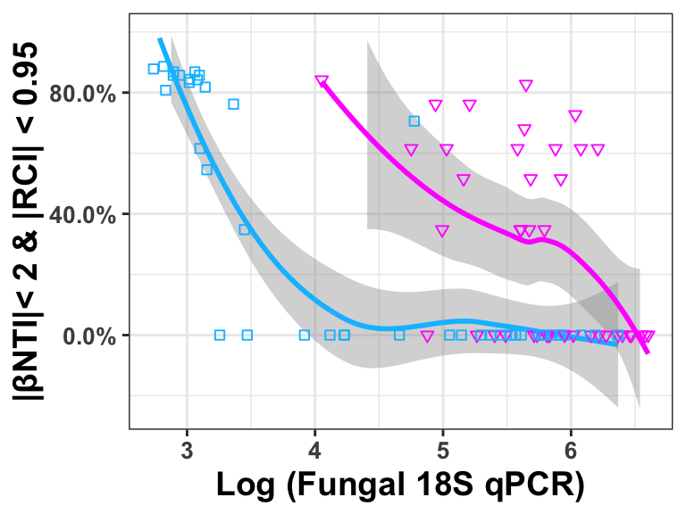

```r
LaggqPCR$Habitat<-factor(LaggqPCR$Habitat, levels = c("Leaf", "Root", "Rhizosphere", "Soil"))

ggplot(data=LaggqPCR, aes(y=bNTI.ghost2RC95pct, x= qPCR , color=Habitat, shape =Habitat) )+
  geom_smooth( method="loess", span=0.9)+ geom_point() + theme_bw()+
  xlab("Log (Fungal 18S qPCR)")+ylab("|βNTI|< 2 & |RCI| < 0.95")+
  scale_color_manual(values = c("deepskyblue","#ff00ff", "gold", "#00ff00"))+ scale_shape_manual(values=c(0, 6, 3, 1))+
  scale_y_continuous(labels = scales::percent, limits = c(-0.25, 1))+
  theme(axis.text=element_text(size=10,face="bold"),
        axis.title=element_text(size=14,face="bold"))+ theme(legend.position = "none")
```

```r
lme0<-lme(bNTI.ghost2RC95pct~qPCR,random=~1|Habitat,data=LaggqPCR)
summary(lme0)
```

```
## Linear mixed-effects model fit by REML
##  Data: LaggqPCR
##        AIC      BIC    logLik
##   27.38686 36.96465 -9.693428
##
## Random effects:
##  Formula: ~1 | Habitat
##         (Intercept) Residual
## StdDev:   0.2235388 0.252787
##
## Fixed effects: bNTI.ghost2RC95pct ~ qPCR
##                  Value Std.Error DF   t-value p-value
## (Intercept)  1.5955085 0.2153519 80  7.408844       0
## qPCR        -0.2563664 0.0283804 80 -9.033222       0
##  Correlation:
##      (Intr)
## qPCR -0.667
##
## Standardized Within-Group Residuals:
##        Min         Q1        Med         Q3        Max
## -2.3988980 -0.5969421  0.1367849  0.6668536  2.0788073
##
## Number of Observations: 83
## Number of Groups: 2
```

```r
anova(lme0)
```

```
##             numDF denDF  F-value p-value
## (Intercept)     1    80  3.45539  0.0667
## qPCR            1    80 81.59909  <.0001
```

```r
r.squaredGLMM(lme0)
```

```
##            R2m       R2c
## [1,] 0.4514272 0.6921557
```

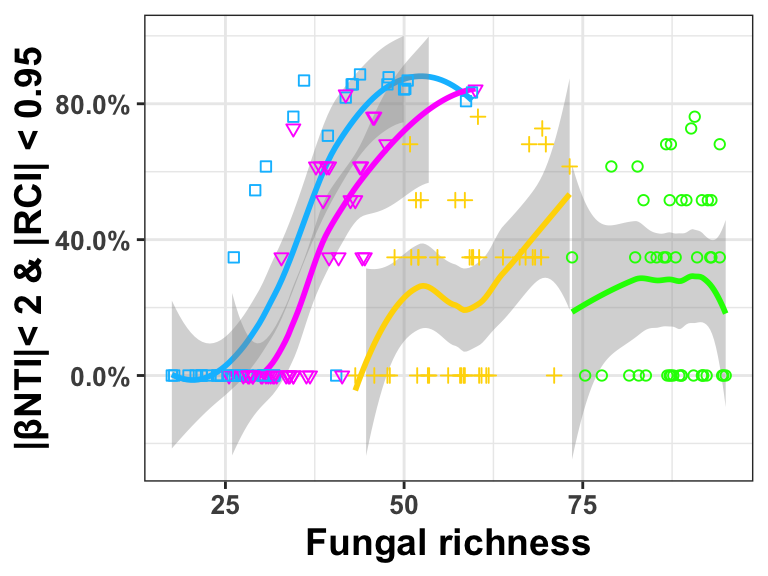

```r
ggplot(data=Lagg, aes(y=bNTI.ghost2RC95pct, x= S.rar362, color=Habitat, shape =Habitat) )+
  geom_smooth( method="loess", span = 0.9)+ geom_point() + theme_bw()+
  xlab("Fungal richness")+ylab("|βNTI|< 2 & |RCI| < 0.95")+
  scale_y_continuous(labels = scales::percent, limits = c(-0.25, 1))+
  scale_color_manual(values = c("deepskyblue","#ff00ff", "gold", "#00ff00"))+ scale_shape_manual(values=c(0, 6, 3, 1))+
  theme(axis.text=element_text(size=10,face="bold"),
        axis.title=element_text(size=14,face="bold"))+ theme(legend.position = "none")
```

```r
lme0<-lme(bNTI.ghost2RC95pct~S.rar362,random=~1|Habitat,data=Lagg)
summary(lme0)
```

```
## Linear mixed-effects model fit by REML
##  Data: Lagg
##        AIC      BIC    logLik
##   51.42467 63.94426 -21.71233
##
## Random effects:
##  Formula: ~1 | Habitat
##         (Intercept)  Residual
## StdDev:   0.5878659 0.2511707
##
## Fixed effects: bNTI.ghost2RC95pct ~ S.rar362
##                  Value Std.Error  DF   t-value p-value
## (Intercept) -0.9449411 0.3221193 166 -2.933513  0.0038
## S.rar362     0.0227299 0.0024126 166  9.421475  0.0000
##  Correlation:
##          (Intr)
## S.rar362 -0.405
##
## Standardized Within-Group Residuals:
##        Min         Q1        Med         Q3        Max
## -2.2140402 -0.7300276 -0.1706985  0.8032086  2.3216688
##
## Number of Observations: 171
## Number of Groups: 4
```

```r
anova(lme0)
```

```
##             numDF denDF  F-value p-value
## (Intercept)     1   166  0.92494  0.3376
## S.rar362        1   166 88.76419  <.0001
```

```r
r.squaredGLMM(lme0)
```

```
##            R2m       R2c
## [1,] 0.4110651 0.9090863
```

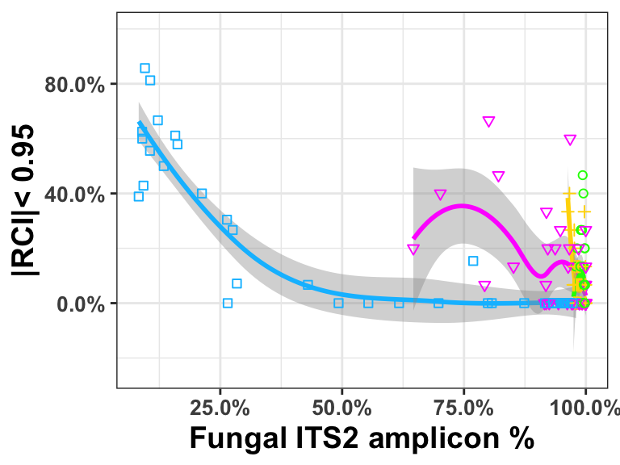

```r
# RC95
ggplot(data=Lagg, aes(y=RC95pct, x= Fungi.pct/100, color=Habitat, shape =Habitat))+
  geom_smooth( method="loess", span=0.9)+ geom_point() + theme_bw()+
  xlab("Fungal ITS2 amplicon %")+ylab("|RCI|< 0.95")+
  scale_color_manual(values = c("deepskyblue","#ff00ff", "gold", "#00ff00"))+ scale_shape_manual(values=c(0, 6, 3, 1))+
  scale_y_continuous(labels = scales::percent, limits = c(-0.25, 1))+
  scale_x_continuous(labels = scales::percent)+
  theme(axis.text=element_text(size=10,face="bold"),
        axis.title=element_text(size=14,face="bold"))+ theme(legend.position = "none")
```

```r
lme0<-lme(RC95pct~Fungi.pct,random=~1|Habitat,data=Lagg)
summary(lme0)
```

```
## Linear mixed-effects model fit by REML
##  Data: Lagg
##         AIC      BIC   logLik
##   -181.3166 -168.797 94.65828
##
## Random effects:
##  Formula: ~1 | Habitat
##         (Intercept) Residual
## StdDev:  0.07294457 0.128637
##
## Fixed effects: RC95pct ~ Fungi.pct
##                  Value  Std.Error  DF   t-value p-value
## (Intercept)  0.6721366 0.05918241 166  11.35703       0
## Fungi.pct   -0.0063162 0.00051885 166 -12.17334       0
##  Correlation:
##           (Intr)
## Fungi.pct -0.77
##
## Standardized Within-Group Residuals:
##        Min         Q1        Med         Q3        Max
## -3.1108596 -0.6399253 -0.1329896  0.3796181  3.9211689
##
## Number of Observations: 171
## Number of Groups: 4
```

```r
anova(lme0)
```

```
##             numDF denDF   F-value p-value
## (Intercept)     1   166   9.68278  0.0022
## Fungi.pct       1   166 148.19028  <.0001
```

```r
r.squaredGLMM(lme0)
```

```
##            R2m       R2c
## [1,] 0.5317515 0.6456834
```

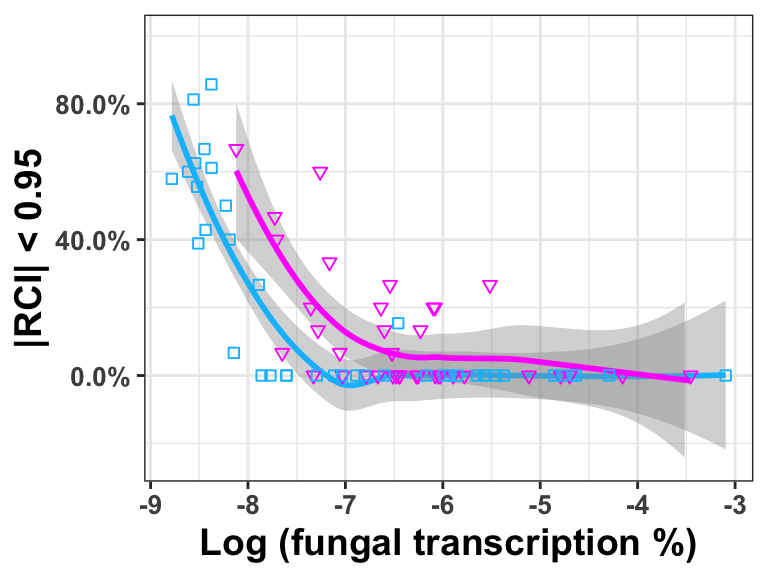

```r
ggplot(data=Traagg, aes(y=RC95pct, x= log(Fungi.pct.tra) , color=Habitat, shape =Habitat) )+
  geom_smooth( method="loess", span=0.9)+ geom_point() + theme_bw()+
  xlab("Log (fungal transcription %)")+ylab("|RCI| < 0.95")+
  scale_color_manual(values = c("deepskyblue","#ff00ff", "gold", "#00ff00"))+ scale_shape_manual(values=c(0, 6, 3, 1))+
  scale_y_continuous(labels = scales::percent, limits = c(-0.25, 1))+
  theme(axis.text=element_text(size=10,face="bold"),
        axis.title=element_text(size=14,face="bold"))+ theme(legend.position = "none")
```

```r
lme0<-lme(RC95pct~log(Fungi.pct.tra),random=~1|Habitat,data=Traagg)
summary(lme0)
```

```
## Linear mixed-effects model fit by REML
##  Data: Traagg
##         AIC       BIC   logLik
##   -28.73916 -19.46921 18.36958
##
## Random effects:
##  Formula: ~1 | Habitat
##          (Intercept)  Residual
## StdDev: 2.852238e-06 0.1781345
##
## Fixed effects: RC95pct ~ log(Fungi.pct.tra)
##                         Value  Std.Error DF   t-value p-value
## (Intercept)        -0.6481421 0.10596212 74 -6.116734       0
## log(Fungi.pct.tra) -0.1211392 0.01569234 74 -7.719641       0
##  Correlation:
##                    (Intr)
## log(Fungi.pct.tra) 0.981
##
## Standardized Within-Group Residuals:
##        Min         Q1        Med         Q3        Max
## -1.7066862 -0.7442016 -0.1437817  0.6382987  2.7542289
##
## Number of Observations: 77
## Number of Groups: 2
```

```r
anova(lme0)
```

```
##                    numDF denDF  F-value p-value
## (Intercept)            1    74 58.06987  <.0001
## log(Fungi.pct.tra)     1    74 59.59285  <.0001
```

```r
r.squaredGLMM(lme0)
```

```
##            R2m       R2c
## [1,] 0.4394985 0.4394985
```

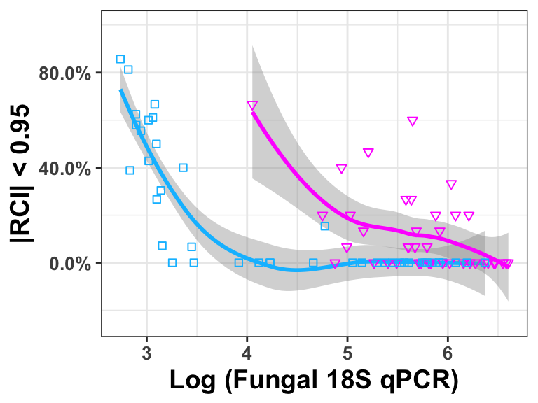

```r
ggplot(data=LaggqPCR, aes(y=RC95pct, x= qPCR , color=Habitat, shape =Habitat) )+
  geom_smooth( method="loess", span=0.9)+ geom_point() + theme_bw()+
  xlab("Log (Fungal 18S qPCR)")+ylab("|RCI| < 0.95")+
  scale_color_manual(values = c("deepskyblue","#ff00ff", "gold", "#00ff00"))+ scale_shape_manual(values=c(0, 6, 3, 1))+
  scale_y_continuous(labels = scales::percent, limits = c(-0.25, 1))+
  theme(axis.text=element_text(size=10,face="bold"),
        axis.title=element_text(size=14,face="bold"))+ theme(legend.position = "none")
```

```r
lme0<-lme(RC95pct~qPCR,random=~1|Habitat,data=LaggqPCR)
summary(lme0)
```

```
## Linear mixed-effects model fit by REML
##  Data: LaggqPCR
##         AIC       BIC   logLik
##   -43.79706 -34.21927 25.89853
##
## Random effects:
##  Formula: ~1 | Habitat
##         (Intercept) Residual
## StdDev:   0.1023014 0.163555
##
## Fixed effects: RC95pct ~ qPCR
##                  Value  Std.Error DF   t-value p-value
## (Intercept)  0.9637773 0.11861702 80  8.125118       0
## qPCR        -0.1605104 0.01823753 80 -8.801106       0
##  Correlation:
##      (Intr)
## qPCR -0.778
##
## Standardized Within-Group Residuals:
##         Min          Q1         Med          Q3         Max
## -2.27474042 -0.51905433 -0.03368199  0.55024814  2.89546886
##
## Number of Observations: 83
## Number of Groups: 2
```

```r
anova(lme0)
```

```
##             numDF denDF  F-value p-value
## (Intercept)     1    80  4.13968  0.0452
## qPCR            1    80 77.45947  <.0001
```

```r
r.squaredGLMM(lme0)
```

```
##            R2m       R2c
## [1,] 0.4967318 0.6382575
```

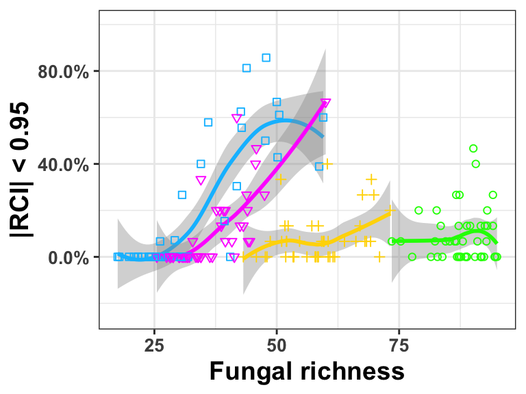

```r
ggplot(data=Lagg, aes(y=RC95pct, x= S.rar362, color=Habitat, shape =Habitat) )+
  geom_smooth( method="loess", span = 0.9)+ geom_point() + theme_bw()+
  xlab("Fungal richness")+ylab("|RCI| < 0.95")+
  scale_color_manual(values = c("deepskyblue","#ff00ff", "gold", "#00ff00"))+ scale_shape_manual(values=c(0, 6, 3, 1))+
  scale_y_continuous(labels = scales::percent, limits = c(-0.25, 1))+
  theme(axis.text=element_text(size=10,face="bold"),
        axis.title=element_text(size=14,face="bold"))+ theme(legend.position = "none")
```

```r
lme0<-lme(RC95pct~S.rar362,random=~1|Habitat,data=Lagg)
summary(lme0)
```

```
## Linear mixed-effects model fit by REML
##  Data: Lagg
##         AIC       BIC   logLik
##   -152.1368 -139.6172 80.06839
##
## Random effects:
##  Formula: ~1 | Habitat
##         (Intercept)  Residual
## StdDev:   0.3844056 0.1371005
##
## Fixed effects: RC95pct ~ S.rar362
##                  Value  Std.Error  DF   t-value p-value
## (Intercept) -0.6295904 0.20534067 166 -3.066077  0.0025
## S.rar362     0.0138275 0.00132329 166 10.449334  0.0000
##  Correlation:
##          (Intr)
## S.rar362 -0.348
##
## Standardized Within-Group Residuals:
##        Min         Q1        Med         Q3        Max
## -2.1206214 -0.6408615 -0.1876052  0.4091803  3.4695007
##
## Number of Observations: 171
## Number of Groups: 4
```

```r
anova(lme0)
```

```
##             numDF denDF   F-value p-value
## (Intercept)     1   166   0.37314  0.5421
## S.rar362        1   166 109.18858  <.0001
```

```r
r.squaredGLMM(lme0)
```

```
##            R2m       R2c
## [1,] 0.3879186 0.9309275
```

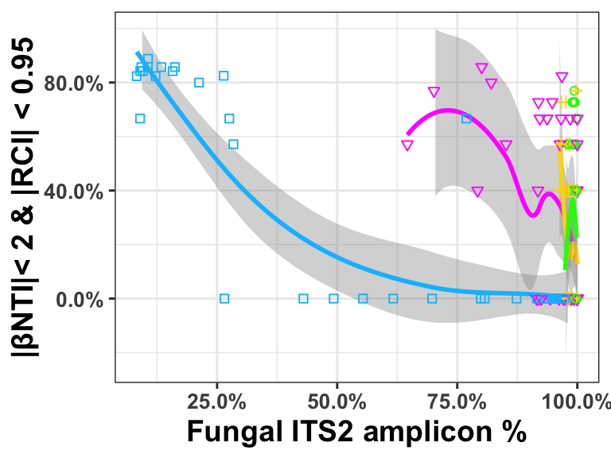

```r
#####RC.bNTI.its2
rm(list = ls())

load("EPICON.data.preparation.RC.bNTI.its2.2019.03.17.Rdata")
Lagg$Habitat<-factor(Lagg$Habitat, levels = c("Leaf", "Root", "Rhizosphere", "Soil"))
ggplot(data=Lagg, aes(y=bNTI.its22RC95pct, x= Fungi.pct/100, color=Habitat, shape =Habitat))+
  geom_smooth( method="loess", span=0.9)+ geom_point() + theme_bw()+
  xlab("Fungal ITS2 amplicon %")+ylab("|βNTI|< 2 & |RCI| < 0.95")+
  scale_color_manual(values = c("deepskyblue","#ff00ff", "gold", "#00ff00"))+ scale_shape_manual(values=c(0, 6, 3, 1))+
  scale_y_continuous(labels = scales::percent, limits = c(-0.25, 1))+
  scale_x_continuous(labels = scales::percent)+
  theme(axis.text=element_text(size=10,face="bold"),
        axis.title=element_text(size=14,face="bold"))+ theme(legend.position = "none")
```

```r
lme0<-lme(bNTI.its22RC95pct~Fungi.pct,random=~1|Habitat,data=Lagg)
summary(lme0)
```

```
## Linear mixed-effects model fit by REML
##  Data: Lagg
##        AIC     BIC    logLik
##   61.94271 74.4623 -26.97135
##
## Random effects:
##  Formula: ~1 | Habitat
##         (Intercept)  Residual
## StdDev:    0.166578 0.2637308
##
## Fixed effects: bNTI.its22RC95pct ~ Fungi.pct
##                  Value  Std.Error  DF   t-value p-value
## (Intercept)  1.1113135 0.12709458 166  8.743988       0
## Fungi.pct   -0.0095087 0.00106895 166 -8.895392       0
##  Correlation:
##           (Intr)
## Fungi.pct -0.738
##
## Standardized Within-Group Residuals:
##         Min          Q1         Med          Q3         Max
## -2.36666784 -0.89688935  0.09781161  0.72110916  2.16273992
##
## Number of Observations: 171
## Number of Groups: 4
```

```r
anova(lme0)
```

```
##             numDF denDF  F-value p-value
## (Intercept)     1   166 10.40474  0.0015
## Fungi.pct       1   166 79.12800  <.0001
```

```r
r.squaredGLMM(lme0)
```

```
##            R2m       R2c
## [1,] 0.3664657 0.5471344
```

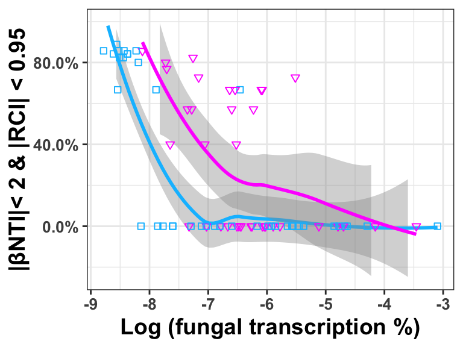

```r
Traagg$Habitat<-factor(Traagg$Habitat, levels = c("Leaf", "Root", "Rhizosphere", "Soil"))
ggplot(data=Traagg, aes(y=bNTI.its22RC95pct, x= log(Fungi.pct.tra) , color=Habitat, shape =Habitat) )+
  geom_smooth( method="loess", span=0.9)+ geom_point() + theme_bw()+
  xlab("Log (fungal transcription %)")+ylab("|βNTI|< 2 & |RCI| < 0.95")+
  scale_y_continuous(labels = scales::percent, limits = c(-0.25, 1))+
  scale_color_manual(values = c("deepskyblue","#ff00ff", "gold", "#00ff00"))+ scale_shape_manual(values=c(0, 6, 3, 1))+
  theme(axis.text=element_text(size=10,face="bold"),
        axis.title=element_text(size=14,face="bold"))+ theme(legend.position = "none")
```

```r
lme0<-lme(bNTI.its22RC95pct~log(Fungi.pct.tra),random=~1|Habitat,data=Traagg)
summary(lme0)
```

```
## Linear mixed-effects model fit by REML
##  Data: Traagg
##        AIC      BIC    logLik
##   42.33073 51.60068 -17.16536
##
## Random effects:
##  Formula: ~1 | Habitat
##         (Intercept)  Residual
## StdDev:   0.0532099 0.2845179
##
## Fixed effects: bNTI.its22RC95pct ~ log(Fungi.pct.tra)
##                         Value  Std.Error DF   t-value p-value
## (Intercept)        -0.8923669 0.17490894 74 -5.101894       0
## log(Fungi.pct.tra) -0.1782131 0.02532588 74 -7.036801       0
##  Correlation:
##                    (Intr)
## log(Fungi.pct.tra) 0.959
##
## Standardized Within-Group Residuals:
##         Min          Q1         Med          Q3         Max
## -1.86615241 -0.89100243  0.03685288  0.91157448  2.13776356
##
## Number of Observations: 77
## Number of Groups: 2
```

```r
anova(lme0)
```

```
##                    numDF denDF  F-value p-value
## (Intercept)            1    74 33.55035  <.0001
## log(Fungi.pct.tra)     1    74 49.51656  <.0001
```

```r
r.squaredGLMM(lme0)
```

```
##            R2m       R2c
## [1,] 0.3912621 0.4118336
```

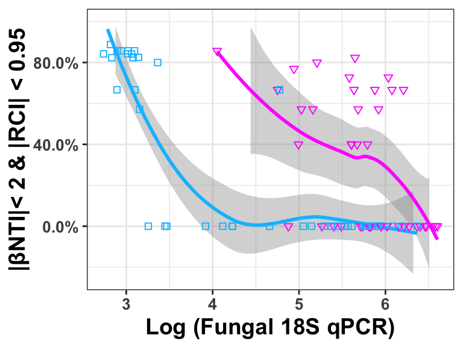

```r
LaggqPCR$Habitat<-factor(LaggqPCR$Habitat, levels = c("Leaf", "Root", "Rhizosphere", "Soil"))
ggplot(data=LaggqPCR, aes(y=bNTI.its22RC95pct, x= qPCR , color=Habitat, shape =Habitat) )+
  geom_smooth( method="loess", span=0.9)+ geom_point() + theme_bw()+
  xlab("Log (Fungal 18S qPCR)")+ylab("|βNTI|< 2 & |RCI| < 0.95")+
  scale_y_continuous(labels = scales::percent, limits = c(-0.25, 1))+
  scale_color_manual(values = c("deepskyblue","#ff00ff", "gold", "#00ff00"))+ scale_shape_manual(values=c(0, 6, 3, 1))+
  theme(axis.text=element_text(size=10,face="bold"),
        axis.title=element_text(size=14,face="bold"))+ theme(legend.position = "none")
```

```r
lme0<-lme(bNTI.its22RC95pct~qPCR,random=~1|Habitat,data=LaggqPCR)
summary(lme0)
```

```
## Linear mixed-effects model fit by REML
##  Data: LaggqPCR
##        AIC      BIC    logLik
##   35.05183 44.62963 -13.52592
##
## Random effects:
##  Formula: ~1 | Habitat
##         (Intercept)  Residual
## StdDev:   0.2397723 0.2649628
##
## Fixed effects: bNTI.its22RC95pct ~ qPCR
##                  Value  Std.Error DF   t-value p-value
## (Intercept)  1.5719530 0.22860872 80  6.876172       0
## qPCR        -0.2511179 0.02975689 80 -8.438982       0
##  Correlation:
##      (Intr)
## qPCR -0.659
##
## Standardized Within-Group Residuals:
##        Min         Q1        Med         Q3        Max
## -2.2212644 -0.6387196  0.1477335  0.7157761  1.9042971
##
## Number of Observations: 83
## Number of Groups: 2
```

```r
anova(lme0)
```

```
##             numDF denDF  F-value p-value
## (Intercept)     1    80  3.06817  0.0837
## qPCR            1    80 71.21642  <.0001
```

```r
r.squaredGLMM(lme0)
```

```
##            R2m       R2c
## [1,] 0.4131728 0.6773716
```

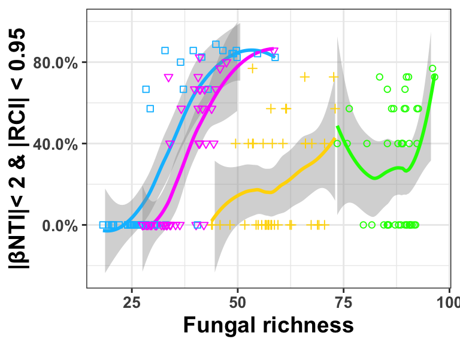

```r
ggplot(data=Lagg, aes(y=bNTI.its22RC95pct, x= S.rar362, color=Habitat, shape =Habitat) )+
  geom_smooth( method="loess", span = 0.9)+ geom_point() + theme_bw()+
  xlab("Fungal richness")+ylab("|βNTI|< 2 & |RCI| < 0.95")+
  scale_y_continuous(labels = scales::percent, limits = c(-0.25, 1))+
  scale_color_manual(values = c("deepskyblue","#ff00ff", "gold", "#00ff00"))+ scale_shape_manual(values=c(0, 6, 3, 1))+
  theme(axis.text=element_text(size=10,face="bold"),
        axis.title=element_text(size=14,face="bold"))+ theme(legend.position = "none")
```

```r
lme0<-lme(bNTI.its22RC95pct~S.rar362,random=~1|Habitat,data=Lagg)
summary(lme0)
```

```
## Linear mixed-effects model fit by REML
##  Data: Lagg
##        AIC      BIC    logLik
##   66.27762 78.79722 -29.13881
##
## Random effects:
##  Formula: ~1 | Habitat
##         (Intercept)  Residual
## StdDev:   0.6033899 0.2625974
##
## Fixed effects: bNTI.its22RC95pct ~ S.rar362
##                  Value Std.Error  DF   t-value p-value
## (Intercept) -0.9975321 0.3338190 166 -2.988242  0.0032
## S.rar362     0.0235755 0.0026179 166  9.005518  0.0000
##  Correlation:
##          (Intr)
## S.rar362 -0.424
##
## Standardized Within-Group Residuals:
##        Min         Q1        Med         Q3        Max
## -1.8533480 -0.7448162 -0.1599908  0.8369160  2.6047314
##
## Number of Observations: 171
## Number of Groups: 4
```

```r
anova(lme0)
```

```
##             numDF denDF  F-value p-value
## (Intercept)     1   166  0.83571   0.362
## S.rar362        1   166 81.09935  <.0001
```

```r
r.squaredGLMM(lme0)
```

```
##            R2m       R2c
## [1,] 0.4124878 0.9064437
```

###### DATA PREPARATION RC BNTI ITS2

setwd(“/Users/chengg/Google Drive/EPICON/Mycobiome/Fungal ITS/statistic/Total.fungi”) library(reshape2) library(ggplot2) library(MASS) library(splitstackshape) library(colorRamps) library(vegan) library(betapart) library(ape) library(DOC) library(ecodist) library(gridExtra) library(nlme) library(MuMIn) source(“weighted Fst function.r”) env0<-read.csv(“epicon.ENV.2017.12.05.csv”, head = T) fung0<-read.csv(“epicon.ID.mat.2018.06.12.csv”, head=T, row.names =1) ##Read in the raw data###

gr<-fung0$Fungi=="Fungi" #gr<-fung0$Phylum==“Basidiomycota”

fungt<-data.frame(fung0[gr ,c(1:1251) ]) ### raw data of all samples including pseudo samples # ID<-data.frame(fung0[gr ,c(-1:-1251) ]) ### raw data of all samples including pseudo samples # ID1<-data.frame(rownames(ID),ID$Phylum_lifestyle, ID$Phylum) #names(ID1)<- c(“ID”, “Phylum_lifestyle”, “Phylum”, “Life_style”) #Flev<-ID$Phylum #Flev<-ID$Phylum_lifestyle Flev<-rownames(ID); taxonomy<-data.frame(ID$Kingdom,ID$Phylum.ab, ID$Class.ab, ID$Order, ID$Family, ID$Genus); colnames(taxonomy) = c(“kingdom”,“phylum”,“class”,“order”,“family”,“genus”); rownames(taxonomy)<-rownames(ID) fung.lev<-data.frame(aggregate(fungt,by=list(Flev) , sum)) rownames(fung.lev)<-fung.lev[,1]; fung.lev<-fung.lev[match(Flev, fung.lev$Group.1),] fung.lev<-fung.lev[,-1] fung1<-data.frame(t(fung.lev))

fung.raw.pseudo<-fung1[env0$Habitat!=“Prop_root”,] # can be useful for Barplots of total fungi env.F.raw.pseudo<-env0[env0$Habitat!=“Prop_root”,] # can be useful for Barplots of total fungi

fung.raw<-fung.raw.pseudo[c(1:1026),] ### raw data of all samples # env.raw<-env.F.raw.pseudo[c(1:1026),]

cutoff<-362 # the cutoff for rarefaction

fung.rar<-data.frame(rrarefy(fung.raw, cutoff))  
env<-env.raw[rowSums(fung.rar)==cutoff,] fung<-fung.rar[rowSums(fung.rar)==cutoff,colSums(fung.rar)>0] fung<-fung[,colSums(fung)>0]

# bNTI.its2

phylo = read.tree(“EPICON.fungi.tree.txt”); #phylo; # a summary of the phylogeny #plot.phylo(phylo,typ=“fan”, font =1, cex=1) bNTI.its2<-read.csv(“weighted_bNTI.its2.F.csv”, head = T, row.names =1) bNTI.its2<-as.dist(bNTI.its2) bNTI.its201<-(bNTI.its2-min(bNTI.its2))/(max(bNTI.its2)-min(bNTI.its2))

# RC

rc0<-read.csv(“rc.RSZL.F.csv”, head = T, row.names =1) rc<-as.dist(rc0) rc01<-(rc+1)/2

env.L<-env fungL.R362F<-fung tmp<-fung ## abudance data

tmp01<-tmp tmp01[tmp01>0]=1 # 0 1 data env.L$S.rar362<-specnumber(fungL.R362F) env.L$H.rar362<-vegan::diversity(fungL.R362F) env.L$J.rar362<-env.L$H.rar362/log(env.L$S.rar362) env.L$TP1[env.L$TP>7]=“Weeks8_17” ; env.L$TP1[env.L$TP<8]=“Weeks1_7” # to divide all time points to early and later groups env.L$bb<-droplevels(interaction( env.L$Timepiont,env.L$Habitat,env.L$Treatment1,sep = “.”)) env.L$Habitat2<-factor(droplevels(env.L$Habitat), levels=c(“Leaf”, “Root”, “Rhizosphere”, “Soil”), labels = c(“L”, “R”, “Z”, “S”)) env.L$aa1<-paste("TP",env.L$TP, env.L$Habitat2,env.L$plot, sep = “”)

env.L$va<-interaction(env.L$TP, env.L$Habitat2)

phylo = read.tree(“EPICON.fungi.tree.txt”); #phylo; # a summary of the phylogeny #plot.phylo(phylo,typ=“fan”, font =1, cex=1) bNTI.its2<-read.csv(“weighted_bNTI.its2.F.csv”, head = T, row.names =1) bNTI.its2<-as.dist(bNTI.its2) bNTI.its201<-(bNTI.its2-min(bNTI.its2))/(max(bNTI.its2)-min(bNTI.its2))

# RC

rc0<-read.csv(“rc.RSZL.F.csv”, head = T, row.names =1) rc<-as.dist(rc0) rc01<-(rc+1)/2

env.L$va<-interaction(env.L$TP, env.L$Habitat2) fd<-beta.pair(tmp01, index.family = "jaccard") bc<-vegdist(tmp) bd.rc<-betadisper(rc01,env.L$va) env.L$RCdisper<-bd.rc$distances bd.bc<-betadisper(bc,env.L$va) env.L$bradisper<-bd.bc$distances bd.jac<-betadisper(fd$beta.jac,env.L$va) env.L$jacdisper<-bd.jac$distances bd.jne<-betadisper(fd$beta.jne,env.L$va) env.L$jnedisper<-bd.jne$distances bd.jtu<-betadisper(fd$beta.jtu,env.L$va) env.L$jtudisper<-bd.jtu$distances bd.bNTI.its201<-betadisper(bNTI.its201,env.L$va) env.L$bNTI.its2disper<-bd.bNTI.its201$distances

# Transcriptome samples level metrics

Tra<-read.csv(“LR.mycotranscriptome.csv”, head = T)

env.Tra<- merge(Tra,env.L, by.x=“aa”, by.y=“aa1”, all =FALSE) env.Tra$Pct.Tra<-rowSums(env.Tra[,c(12:20,22:24)])/env.Tra$FilteredReads tmp.Tra<-tmp[rownames(tmp) %in% env.Tra$aa,] tmp.Tra<-tmp.Tra[colSums(tmp.Tra)>0] ## abudance data tmp.Tra01<-tmp.Tra tmp.Tra01[tmp.Tra01>0]=1

# Metabolome samples level metrics

Met<-read.csv(“EPICON.metabolome.csv”, head = T) env.Tra.Met<-env.Tra[env.Tra$aa %in% Met$aa,] Met1<-Met[Met$aa %in% env.Tra.Met$aa,] tmp.Tra.Met<-tmp.Tra[rownames(tmp.Tra) %in% env.Tra.Met$aa,]## abudance data tmp.Tra.Met01<-tmp.Tra.Met tmp.Tra.Met01[tmp.Tra.Met01>0]=1

## To aggarete variables by TP.TREAT

bNTI.its2<-read.csv(“weighted_bNTI.its2.S.F.csv”, head = T, row.names =1) bNTI.its2<-as.dist(bNTI.its2) bNTI.its2.01<-(bNTI.its2-min(bNTI.its2))/(max(bNTI.its2)-min(bNTI.its2))

rc0<-read.csv(“rc.S.F.csv”, head = T, row.names =1) rc<-as.dist(rc0) rc.01<-(rc+1)/2

env.L1<-droplevels(env.L[env.L$Habitat==“Soil”,])

t1<-levels(env.L1$bb) LbNTI.its2 = NULL for (i in t1){ m1<-as.matrix(bNTI.its2)[grep(i, env.L1$bb), grep(i, env.L1$bb) ] m1<-data.frame(melt(m1[lower.tri(m1, diag = FALSE)])) m1$TP.TREAT=i #m1$Habitat="Leaf" LbNTI.its2<-rbind(LbNTI.its2,m1) } LbNTI.its22<-cSplit(LbNTI.its2, "TP.TREAT", ".") LbNTI.its22$TP.TREAT_1<-as.numeric(gsub(“TP”, “” , LbNTI.its22$TP.TREAT_1)) LbNTI.its2.TP.TREAT<-LbNTI.its22 names(LbNTI.its2.TP.TREAT)<-c("bNTI.its2", "TP","Habitat", "Treatment") LbNTI.its2<-data.frame(LbNTI.its2$TP.TREAT,LbNTI.its2.TP.TREAT) names(LbNTI.its2)<-c(“TP.TREAT”, “bNTI.its2”, “TP”,“Habitat”, “Treatment”) # RC t1<-levels(env.L1$bb) Lrc = NULL for (i in t1){ m1<-as.matrix(rc)[grep(i, env.L1$bb), grep(i, env.L1$bb) ] m1<-data.frame(melt(m1[lower.tri(m1, diag = FALSE)])) m1$TP.TREAT=i #m1$Habitat="Leaf" Lrc<-rbind(Lrc,m1) } Lrc2<-cSplit(Lrc, "TP.TREAT", ".") Lrc2$TP.TREAT_1<-as.numeric(gsub(“TP”, “” , Lrc2$TP.TREAT_1)) RC.TP.TREAT<-Lrc2 names(RC.TP.TREAT)<-c("RC", "TP","Habitat", "Treatment") Lrc<-data.frame(Lrc$TP.TREAT,Lrc2) names(Lrc)<-c(“TP.TREAT”, “RC”, “TP”,“Habitat”, “Treatment”) LbNTI.its2.S<-LbNTI.its2 Lrc.S<-Lrc

bNTI.its2<-read.csv(“weighted_bNTI.its2.Z.F.csv”, head = T, row.names =1) bNTI.its2<-as.dist(bNTI.its2) bNTI.its2.01<-(bNTI.its2-min(bNTI.its2))/(max(bNTI.its2)-min(bNTI.its2))

rc0<-read.csv(“rc.Z.F.csv”, head = T, row.names =1) rc<-as.dist(rc0) rc.01<-(rc+1)/2

env.L1<-droplevels(env.L[env.L$Habitat==“Rhizosphere”,])

t1<-levels(env.L1$bb) LbNTI.its2 = NULL for (i in t1){ m1<-as.matrix(bNTI.its2)[grep(i, env.L1$bb), grep(i, env.L1$bb) ] m1<-data.frame(melt(m1[lower.tri(m1, diag = FALSE)])) m1$TP.TREAT=i #m1$Habitat="Leaf" LbNTI.its2<-rbind(LbNTI.its2,m1) } LbNTI.its22<-cSplit(LbNTI.its2, "TP.TREAT", ".") LbNTI.its22$TP.TREAT_1<-as.numeric(gsub(“TP”, “” , LbNTI.its22$TP.TREAT_1)) LbNTI.its2.TP.TREAT<-LbNTI.its22 names(LbNTI.its2.TP.TREAT)<-c("bNTI.its2", "TP","Habitat", "Treatment") LbNTI.its2<-data.frame(LbNTI.its2$TP.TREAT,LbNTI.its2.TP.TREAT) names(LbNTI.its2)<-c(“TP.TREAT”, “bNTI.its2”, “TP”,“Habitat”, “Treatment”) # RC t1<-levels(env.L1$bb) Lrc = NULL for (i in t1){ m1<-as.matrix(rc)[grep(i, env.L1$bb), grep(i, env.L1$bb) ] m1<-data.frame(melt(m1[lower.tri(m1, diag = FALSE)])) m1$TP.TREAT=i #m1$Habitat="Leaf" Lrc<-rbind(Lrc,m1) } Lrc2<-cSplit(Lrc, "TP.TREAT", ".") Lrc2$TP.TREAT_1<-as.numeric(gsub(“TP”, “” , Lrc2$TP.TREAT_1)) RC.TP.TREAT<-Lrc2 names(RC.TP.TREAT)<-c("RC", "TP","Habitat", "Treatment") Lrc<-data.frame(Lrc$TP.TREAT,Lrc2) names(Lrc)<-c(“TP.TREAT”, “RC”, “TP”,“Habitat”, “Treatment”) LbNTI.its2.Z<-LbNTI.its2 Lrc.Z<-Lrc

bNTI.its2<-read.csv(“weighted_bNTI.its2.R.F.csv”, head = T, row.names =1) bNTI.its2<-as.dist(bNTI.its2) bNTI.its2.01<-(bNTI.its2-min(bNTI.its2))/(max(bNTI.its2)-min(bNTI.its2))

rc0<-read.csv(“rc.R.F.csv”, head = T, row.names =1) rc<-as.dist(rc0) rc.01<-(rc+1)/2

env.L1<-droplevels(env.L[env.L$Habitat==“Root”,])

t1<-levels(env.L1$bb) LbNTI.its2 = NULL for (i in t1){ m1<-as.matrix(bNTI.its2)[grep(i, env.L1$bb), grep(i, env.L1$bb) ] m1<-data.frame(melt(m1[lower.tri(m1, diag = FALSE)])) m1$TP.TREAT=i #m1$Habitat="Leaf" LbNTI.its2<-rbind(LbNTI.its2,m1) } LbNTI.its22<-cSplit(LbNTI.its2, "TP.TREAT", ".") LbNTI.its22$TP.TREAT_1<-as.numeric(gsub(“TP”, “” , LbNTI.its22$TP.TREAT_1)) LbNTI.its2.TP.TREAT<-LbNTI.its22 names(LbNTI.its2.TP.TREAT)<-c("bNTI.its2", "TP","Habitat", "Treatment") LbNTI.its2<-data.frame(LbNTI.its2$TP.TREAT,LbNTI.its2.TP.TREAT) names(LbNTI.its2)<-c(“TP.TREAT”, “bNTI.its2”, “TP”,“Habitat”, “Treatment”) # RC t1<-levels(env.L1$bb) Lrc = NULL for (i in t1){ m1<-as.matrix(rc)[grep(i, env.L1$bb), grep(i, env.L1$bb) ] m1<-data.frame(melt(m1[lower.tri(m1, diag = FALSE)])) m1$TP.TREAT=i #m1$Habitat="Leaf" Lrc<-rbind(Lrc,m1) } Lrc2<-cSplit(Lrc, "TP.TREAT", ".") Lrc2$TP.TREAT_1<-as.numeric(gsub(“TP”, “” , Lrc2$TP.TREAT_1)) RC.TP.TREAT<-Lrc2 names(RC.TP.TREAT)<-c("RC", "TP","Habitat", "Treatment") Lrc<-data.frame(Lrc$TP.TREAT,Lrc2) names(Lrc)<-c(“TP.TREAT”, “RC”, “TP”,“Habitat”, “Treatment”) LbNTI.its2.R<-LbNTI.its2 Lrc.R<-Lrc

bNTI.its2<-read.csv(“weighted_bNTI.its2.L.F.csv”, head = T, row.names =1) bNTI.its2<-as.dist(bNTI.its2) bNTI.its2.01<-(bNTI.its2-min(bNTI.its2))/(max(bNTI.its2)-min(bNTI.its2))

rc0<-read.csv(“rc.L.F.csv”, head = T, row.names =1) rc<-as.dist(rc0) rc.01<-(rc+1)/2

env.L1<-droplevels(env.L[env.L$Habitat==“Leaf”,])

t1<-levels(env.L1$bb) LbNTI.its2 = NULL for (i in t1){ m1<-as.matrix(bNTI.its2)[grep(i, env.L1$bb), grep(i, env.L1$bb) ] m1<-data.frame(melt(m1[lower.tri(m1, diag = FALSE)])) m1$TP.TREAT=i #m1$Habitat="Leaf" LbNTI.its2<-rbind(LbNTI.its2,m1) } LbNTI.its22<-cSplit(LbNTI.its2, "TP.TREAT", ".") LbNTI.its22$TP.TREAT_1<-as.numeric(gsub(“TP”, “” , LbNTI.its22$TP.TREAT_1)) LbNTI.its2.TP.TREAT<-LbNTI.its22 names(LbNTI.its2.TP.TREAT)<-c("bNTI.its2", "TP","Habitat", "Treatment") LbNTI.its2<-data.frame(LbNTI.its2$TP.TREAT,LbNTI.its2.TP.TREAT) names(LbNTI.its2)<-c(“TP.TREAT”, “bNTI.its2”, “TP”,“Habitat”, “Treatment”) # RC t1<-levels(env.L1$bb) Lrc = NULL for (i in t1){ m1<-as.matrix(rc)[grep(i, env.L1$bb), grep(i, env.L1$bb) ] m1<-data.frame(melt(m1[lower.tri(m1, diag = FALSE)])) m1$TP.TREAT=i #m1$Habitat="Leaf" Lrc<-rbind(Lrc,m1) } Lrc2<-cSplit(Lrc, "TP.TREAT", ".") Lrc2$TP.TREAT_1<-as.numeric(gsub(“TP”, “” , Lrc2$TP.TREAT_1)) RC.TP.TREAT<-Lrc2 names(RC.TP.TREAT)<-c("RC", "TP","Habitat", "Treatment") Lrc<-data.frame(Lrc$TP.TREAT,Lrc2) names(Lrc)<-c(“TP.TREAT”, “RC”, “TP”,“Habitat”, “Treatment”)

LbNTI.its2.L<-LbNTI.its2 Lrc.L<-Lrc

LbNTI.its2<-rbind(LbNTI.its2.L , LbNTI.its2.Z, LbNTI.its2.R,LbNTI.its2.S ) Lrc<-rbind(Lrc.L , Lrc.Z, Lrc.R,Lrc.S )

da<-Lrc da1<-da[da$RC<=-0.95,] y <- NULL; t1<-levels(env.L$bb) for (i in t1){ tmp0<-nrow(da[da1$TP.TREAT== i,]) tmp1<-data.frame(tmp0,i) y<-rbind(y, tmp1) } da2<-da[da$RC>-0.95 & da$RC<0.95,] z <- NULL; for (i in t1){ tmp0<-nrow(da2[da2$TP.TREAT== i,]) tmp1<-data.frame(tmp0,i) z<-rbind(z, tmp1) } da3<-da[da$RC>0.95,] x <- NULL; for (i in t1){ tmp0<-nrow(da3[da3$TP.TREAT== i,]) tmp1<-data.frame(tmp0,i) x<-rbind(x, tmp1) } xyz<-data.frame(y,z,x) xyz$RC95pct<-z$tmp/(x$tmp+y$tmp+z$tmp) LaggRC<-data.frame(xyz$i,xyz$RC95pct) names(LaggRC)<-c("TP.TREAT", "RC95pct") # bNTI.its2 da<-LbNTI.its2 da1<-da[da$bNTI.its2<=-2,] y <- NULL; for (i in t1){ tmp0<-nrow(da[da1$TP.TREAT== i,]) tmp1<-data.frame(tmp0,i) y<-rbind(y, tmp1) } da2<-da[da$bNTI.its2>-2 & da$bNTI.its2<2,] z <- NULL; for (i in t1){ tmp0<-nrow(da2[da2$TP.TREAT== i,]) tmp1<-data.frame(tmp0,i) z<-rbind(z, tmp1) } da3<-da[da$bNTI.its2>2,] x <- NULL; for (i in t1){ tmp0<-nrow(da3[da3$TP.TREAT== i,]) tmp1<-data.frame(tmp0,i) x<-rbind(x, tmp1) } xyz<-data.frame(y,z,x) xyz$bNTI.its22pct<-z$tmp/(x$tmp+y$tmp+z$tmp) Lagg2bNTI.its2<-data.frame(xyz$i,xyz$bNTI.its22pct) names(Lagg2bNTI.its2)<-c(“TP.TREAT”, “bNTI.its22pct”)

# Lagg2bNTI.its2

# LbNTI.its2$TP.TREAT==Lrc$TP.TREAT

Lrc.bNTI.its2<-data.frame(Lrc, LbNTI.its2) #Lrc.bNTI.its2$TP.TREAT==Lrc.bNTI.its2$TP.TREAT.1

Lrc.bNTI.its2<-data.frame(Lrc.bNTI.its2,1)

da<-Lrc.bNTI.its2 da1<-da[da$bNTI.its2>-2 & da$bNTI.its2<2 & da$RC> -0.95 & da$RC < 0.95 ,] y <- NULL; for (i in t1){ tmp0<-nrow(da[da1$TP.TREAT== i,]) tmp1<-data.frame(tmp0,i) y<-rbind(y, tmp1) }

da2<-da[-(da$bNTI.its2>-2 & da$bNTI.its2<2 & da$RC> -0.95 & da$RC < 0.95),] z <- NULL; for (i in t1){ tmp0<-nrow(da2[da2$TP.TREAT== i,]) tmp1<-data.frame(tmp0,i) z<-rbind(z, tmp1) }

xyz<-data.frame(y,z) xyz$bNTI.its22RC95pct<-y$tmp/(y$tmp+z$tmp) Lagg2bNTI.its22RC95pct<-data.frame(xyz$i,xyz$bNTI.its22RC95pct) names(Lagg2bNTI.its22RC95pct)<-c(“TP.TREAT”, “bNTI.its22RC95pct”)

# aggregate(Lrc.bNTI.its2$X1, by=list(Occurence=Lrc.bNTI.its2$TP.TREAT), FUN=sum)

da<-Lrc.bNTI.its2

da1<-da[da$RC<= -0.95,] y1 <- NULL; for (i in t1){ tmp0<-nrow(da1[da1$TP.TREAT== i,]) tmp1<-data.frame(tmp0,i) y1<-rbind(y1, tmp1) } y1<-data.frame(y1, “RC <= -0.95”) names(y1)<-c(“Value”, “TP.TREAT”, “RC.partition”)

da2<-da[abs(da$RC)< 0.95,] y2 <- NULL; for (i in t1){ tmp0<-nrow(da2[da2$TP.TREAT== i,]) tmp1<-data.frame(tmp0,i) y2<-rbind(y2, tmp1) } y2<-data.frame(y2, “abs(RC) < 0.95”) names(y2)<-c(“Value”, “TP.TREAT”, “RC.partition”)

da3<-da[da$RC>=0.95,] y3 <- NULL; for (i in t1){ tmp0<-nrow(da3[da3$TP.TREAT== i,]) tmp1<-data.frame(tmp0,i) y3<-rbind(y3, tmp1) } y3<-data.frame(y3, “RC >= 0.95”) names(y3)<-c(“Value”, “TP.TREAT”, “RC.partition”)

RC.part<-rbind(y1,y2,y3)

# RC.part$TP.TREAT RC.part2<-cSplit(RC.part, "TP.TREAT", ".") RC.part2$TP.TREAT_1<-as.numeric(gsub(“TP”, “” , RC.part2$TP.TREAT_1))

RC.part.TP.TREAT<-RC.part2 names(RC.part.TP.TREAT)<-c(“Value”,“RC.partition”, “TP”, “Habitat”, “Treatment”)

da<-Lrc.bNTI.its2

da1<-da[da$bNTI.its2<= -2,] y1 <- NULL; for (i in t1){ tmp0<-nrow(da1[da1$TP.TREAT== i,]) tmp1<-data.frame(tmp0,i) y1<-rbind(y1, tmp1) } y1<-data.frame(y1, “bNTI.its2 <= -2”) names(y1)<-c(“Value”, “TP.TREAT”, “bNTI.its2.partition”)

da2<-da[abs(da$bNTI.its2)< 2,] y2 <- NULL; for (i in t1){ tmp0<-nrow(da2[da2$TP.TREAT== i,]) tmp1<-data.frame(tmp0,i) y2<-rbind(y2, tmp1) } y2<-data.frame(y2, “abs(bNTI.its2) < 2”) names(y2)<-c(“Value”, “TP.TREAT”, “bNTI.its2.partition”)

da3<-da[da$bNTI.its2>=2,] y3 <- NULL; for (i in t1){ tmp0<-nrow(da3[da3$TP.TREAT== i,]) tmp1<-data.frame(tmp0,i) y3<-rbind(y3, tmp1) } y3<-data.frame(y3, “bNTI.its2 >= 2”) names(y3)<-c(“Value”, “TP.TREAT”, “bNTI.its2.partition”)

bNTI.its2.part<-rbind(y1,y2,y3)

# bNTI.its2.part$TP.TREAT bNTI.its2.part2<-cSplit(bNTI.its2.part, "TP.TREAT", ".") bNTI.its2.part2$TP.TREAT_1<-as.numeric(gsub(“TP”, “” , bNTI.its2.part2$TP.TREAT_1))

bNTI.its2.part.TP.TREAT<-bNTI.its2.part2 names(bNTI.its2.part.TP.TREAT)<-c(“Value”,“bNTI.its2.partition”, “TP”, “Habitat”, “Treatment”) # da<-Lrc.bNTI.its2

da1<-da[abs(da$bNTI.its2)<2 & da$RC<= -0.95,] y1 <- NULL; for (i in t1){ tmp0<-nrow(da1[da1$TP.TREAT== i,]) tmp1<-data.frame(tmp0,i) y1<-rbind(y1, tmp1) } y1<-data.frame(y1, “abs(bNTI.its2) < 2 & RC <= -0.95”) names(y1)<-c(“Value”, “TP.TREAT”, “bNTI.its2.RC.partition”)

da2<-da[abs(da$bNTI.its2)< 2 & abs(da$RC)< 0.95,] y2 <- NULL; for (i in t1){ tmp0<-nrow(da2[da2$TP.TREAT== i,]) tmp1<-data.frame(tmp0,i) y2<-rbind(y2, tmp1) } y2<-data.frame(y2, “abs(bNTI.its2) < 2 & abs(RC) < 0.95”) names(y2)<-c(“Value”, “TP.TREAT”, “bNTI.its2.RC.partition”)

da3<-da[abs(da$bNTI.its2)<2 & da$RC>=0.95,] y3 <- NULL; for (i in t1){ tmp0<-nrow(da3[da3$TP.TREAT== i,]) tmp1<-data.frame(tmp0,i) y3<-rbind(y3, tmp1) } y3<-data.frame(y3, “abs(bNTI.its2) < 2 & RC >= 0.95”) names(y3)<-c(“Value”, “TP.TREAT”, “bNTI.its2.RC.partition”)

da4<-da[da$bNTI.its2>=2 & da$RC>=0.95,] y4 <- NULL; for (i in t1){ tmp0<-nrow(da4[da4$TP.TREAT== i,]) tmp1<-data.frame(tmp0,i) y4<-rbind(y4, tmp1) }

y4<-data.frame(y4, “bNTI.its2 >= 2 & RC >= 0.95”) names(y4)<-c(“Value”, “TP.TREAT”, “bNTI.its2.RC.partition”)

da5<-da[da$bNTI.its2>=2 & abs(da$RC)< 0.95,] y5 <- NULL; for (i in t1){ tmp0<-nrow(da5[da5$TP.TREAT== i,]) tmp1<-data.frame(tmp0,i) y5<-rbind(y5, tmp1) }

y5<-data.frame(y5, “bNTI.its2 >= 2 & abs(RC) < 0.95”) names(y5)<-c(“Value”, “TP.TREAT”, “bNTI.its2.RC.partition”)

da6<-da[da$bNTI.its2>=2 & da$RC<= -0.95,] y6 <- NULL; for (i in t1){ tmp0<-nrow(da6[da6$TP.TREAT== i,]) tmp1<-data.frame(tmp0,i) y6<-rbind(y6, tmp1) }

y6<-data.frame(y6, “bNTI.its2 >= 2 & RC <= -0.95”) names(y6)<-c(“Value”, “TP.TREAT”, “bNTI.its2.RC.partition”)

da7<-da[da$bNTI.its2<= -2 & da$RC>=0.95,] y7 <- NULL; for (i in t1){ tmp0<-nrow(da7[da7$TP.TREAT== i,]) tmp1<-data.frame(tmp0,i) y7<-rbind(y7, tmp1) }

y7<-data.frame(y7, “bNTI.its2 <= -2 & RC >= 0.95”) names(y7)<-c(“Value”, “TP.TREAT”, “bNTI.its2.RC.partition”)

da8<-da[da$bNTI.its2<= -2 & abs(da$RC)< 0.95,] y8 <- NULL; for (i in t1){ tmp0<-nrow(da8[da8$TP.TREAT== i,]) tmp1<-data.frame(tmp0,i) y8<-rbind(y8, tmp1) }

y8<-data.frame(y8, “bNTI.its2 <= -2 & abs(RC) < 0.95”) names(y8)<-c(“Value”, “TP.TREAT”, “bNTI.its2.RC.partition”)

da9<-da[da$bNTI.its2<= -2 & da$RC<= -0.95,] y9 <- NULL; for (i in t1){ tmp0<-nrow(da9[da9$TP.TREAT== i,]) tmp1<-data.frame(tmp0,i) y9<-rbind(y9, tmp1) }

y9<-data.frame(y9, “bNTI.its2 <= -2 & RC < -0.95”) names(y9)<-c(“Value”, “TP.TREAT”, “bNTI.its2.RC.partition”)

# y6 <-15 - (y1$Value+y2$Value+y3$Value+y4$Value+y5$Value+y6$Value+y7$Value+y8$Value+y9$Value) #y6<-data.frame(y6,y1$TP.TREAT, “Others”)

# names(y6)<-c(“Value”, “TP.TREAT”, “bNTI.its2.RC.partition”)

bNTI.its2.RC.part<-rbind(y1,y2,y3,y4,y5, y6, y7, y8,y9)

# bNTI.its2.RC.part$TP.TREAT bNTI.its2.RC.part2<-cSplit(bNTI.its2.RC.part, "TP.TREAT", ".") bNTI.its2.RC.part2$TP.TREAT_1<-as.numeric(gsub(“TP”, “” , bNTI.its2.RC.part2$TP.TREAT_1))

bNTI.its2.RC.part.TP.TREAT<-bNTI.its2.RC.part2 names(bNTI.its2.RC.part.TP.TREAT)<-c(“Value”,“bNTI.its2.RC.partition”, “TP”, “Habitat”, “Treatment”)

# SCNM

source(“sncm.fit.R”) #tmp<-read.csv(“fungL.R362F.csv”, head =T, row.names =1) d.ck<-data.frame() for (j in c(“Root”, “Rhizosphere”, “Leaf”, “Soil”)){ for (i in c(1:17)){ tmp0<-tmp[env.L$Treatment1=="Control" & env.L$Habitat== j & env.L$TP== i,] dd<-data.frame(sncm.fit(tmp0),j,i, “Control”) d.ck<-rbind(d.ck, dd) } }

tmp0<-tmp[env.L$Treatment1=="Control" & env.L$Habitat== “Soil” & env.L$TP== 0,] dd<-data.frame(sncm.fit(tmp0),“Soil”, 0 , “Control”) names(dd)<-names(d.ck) d.ck<-rbind(d.ck, dd)

tmp0<-tmp[env.L$Treatment1=="Pre_flowering_drought" & env.L$Habitat== “Soil” & env.L$TP== 0,] dd<-data.frame(sncm.fit(tmp0),“Soil”, 0 , “Pre_flowering_drought”) names(dd)<-names(d.ck) d.ck<-rbind(d.ck, dd)

tmp0<-tmp[env.L$Treatment1=="Post_flowering_drought" & env.L$Habitat== “Soil” & env.L$TP== 0,] dd<-data.frame(sncm.fit(tmp0),“Soil”, 0 , “Post_flowering_drought”) names(dd)<-names(d.ck) d.ck<-rbind(d.ck, dd)

d.pr<-data.frame() for (j in c(“Root”, “Rhizosphere”, “Leaf”, “Soil”)){ for (i in c(3:17)){ tmp0<-tmp[env.L$Treatment1=="Pre_flowering_drought" & env.L$Habitat== j & env.L$TP== i,] dd<-data.frame(sncm.fit(tmp0),j,i, “Pre_flowering_drought”) d.pr<-rbind(d.pr, dd) } }

d.po<-data.frame() for (j in c(“Root”, “Rhizosphere”, “Leaf”, “Soil”)){ for (i in c(8:17)){ tmp0<-tmp[env.L$Treatment1=="Post_flowering_drought"& env.L$Habitat== j & env.L$TP== i,] dd<-data.frame(sncm.fit(tmp0),j,i, “Post_flowering_drought”) d.po<-rbind(d.po, dd) } } names(d.po)<-names(d.pr)<-names(d.ck) L.sncm<-rbind(d.po,d.pr,d.ck) #L.sncm$X.Control. L.sncm$lev<-interaction(L.sncm$j,L.sncm$X.Control.,L.sncm$i,sep = “:”) names(L.sncm)<-c( “m”,“m.ci”,“m.mle”,“maxLL”,“binoLL”,“poisLL”,“Rsqr”,“Rsqr.bino”,“Rsqr.pois”,“RMSE”,“RMSE.bino”,“RMSE.pois”,“AIC”,“BIC”,“AIC.bino”,“BIC.bino”,“AIC.pois”,“BIC.pois”,“N”,“Samples”,“Richness”,“Detect”,“Habitat”, “TP”, “Treatment”,“Level”)

t1<-levels(droplevels(env.L$bb)) Fst = NULL for (i in t1){ m1<-w.fst(tmp[env.L$bb== i,]) m1<-data.frame(m1, i) Fst<-rbind(Fst,m1) } names(Fst)<-c(“Fst”, “TP.TREAT”)

phylo = read.tree(“EPICON.fungi.tree.txt”); #phylo; # a summary of the phylogeny #plot.phylo(phylo,typ=“fan”, font =1, cex=1) bNTI.its2<-read.csv(“weighted_bNTI.its2.F.csv”, head = T, row.names =1) bNTI.its2<-as.dist(bNTI.its2) bNTI.its201<-(bNTI.its2-min(bNTI.its2))/(max(bNTI.its2)-min(bNTI.its2))

# RC

rc0<-read.csv(“rc.RSZL.F.csv”, head = T, row.names =1) rc<-as.dist(rc0) rc01<-(rc+1)/2

env.L$va<-interaction(env.L$TP, env.L$Habitat2) fd<-beta.pair(tmp01, index.family = "jaccard") bc<-vegdist(tmp) bd.rc<-betadisper(rc01,env.L$va) env.L$RCdisper<-bd.rc$distances bd.bc<-betadisper(bc,env.L$va) env.L$bradisper<-bd.bc$distances bd.jac<-betadisper(fd$beta.jac,env.L$va) env.L$jacdisper<-bd.jac$distances bd.jne<-betadisper(fd$beta.jne,env.L$va) env.L$jnedisper<-bd.jne$distances bd.jtu<-betadisper(fd$beta.jtu,env.L$va) env.L$jtudisper<-bd.jtu$distances bd.bNTI.its201<-betadisper(bNTI.its201,env.L$va) env.L$bNTI.its2disper<-bd.bNTI.its201$distances

# env.L$Fungi.pct<-rowSums(fungL.rawF)/colSums(fung0.L[,26:277]) env.L$S.raw<-specnumber(fung.raw)

env.L$S.rar362<-specnumber(tmp) env.L$OTU15_Ustilago<-tmp$OTU15_Ustilago env.L$yeasts<-tmp$OTU26_Sporobolomyces+tmp$OTU10_Filobasidium+tmp$OTU24_Cryptococcus+tmp$OTU14_Symmetrospora Laggmeta<-aggregate(cbind(env.L$Fungi.pct, env.L$S.raw, env.L$S.rar362,env.L$RCdisper, env.L$bradisper, env.L$jacdisper, env.L$jnedisper, env.L$jtudisper),by=list(env.L$bb) , mean) names(Laggmeta)<-c(“TP.TREAT”,“Fungi.pct”, “S.raw”, “S.rar362”, “RCdisper”, “bradisper”, “jacdisper”, “jnedisper”, “jtudisper”) Lagg<-merge(LaggRC, Laggmeta, by=“TP.TREAT”, all = FALSE) Lagg<-merge(Lagg, Lagg2bNTI.its2, by=“TP.TREAT”, all = FALSE) Lagg<-merge(Lagg, Lagg2bNTI.its22RC95pct, by=“TP.TREAT”, all = FALSE)

fung.L1<-cSplit(Lagg, “TP.TREAT”, “.”) fung.L1$TP.TREAT_1<-as.numeric(gsub("TP", "" , fung.L1$TP.TREAT_1)) fung.L1$Level<-interaction(fung.L1$TP.TREAT_2,fung.L1$TP.TREAT_3 ,fung.L1$TP.TREAT_1 ,sep = “:”) Lagg<-data.frame(fung.L1$Level,Lagg) Lagg<-merge(Lagg, L.sncm, by.x="fung.L1.Level", by.y= "Level", all= TRUE ) #L.sncm$Level #Lagg$fung.L1.Level Lagg<-merge(Lagg,Fst, by=“TP.TREAT”)

## LaggqPCR

env.LqPCR<-env.L[env.L$qPCR > 0, ] LaggqPCRmeta<-aggregate(cbind(env.LqPCR$Fungi.pct,env.LqPCR$qPCR, env.LqPCR$S.raw, env.LqPCR$S.rar362, env.LqPCR$RCdisper, env.LqPCR$bradisper, env.LqPCR$jacdisper, env.LqPCR$jnedisper,env.LqPCR$jtudisper),by=list(env.LqPCR$bb) , mean)

names(LaggqPCRmeta)<-c(“TP.TREAT”,“Fungi.pct”, “qPCR”, “S.raw”, “S.rar362”, “RCdisper”, “bradisper”, “jacdisper”, “jnedisper”, “jtudisper”)

LaggqPCR<-merge(LaggRC, LaggqPCRmeta, by=“TP.TREAT”, all = FALSE) LaggqPCR<-merge(LaggqPCR, Lagg2bNTI.its2, by=“TP.TREAT”, all = FALSE) LaggqPCR<-merge(LaggqPCR, Lagg2bNTI.its22RC95pct, by=“TP.TREAT”, all = FALSE)

fung.L1qPCR<-cSplit(LaggqPCR, “TP.TREAT”, “.”) fung.L1qPCR$TP.TREAT_1<-as.numeric(gsub("TP", "" , fung.L1qPCR$TP.TREAT_1)) fung.L1qPCR$Level<-interaction(fung.L1qPCR$TP.TREAT_2,fung.L1qPCR$TP.TREAT_3 ,fung.L1qPCR$TP.TREAT_1 ,sep = “:”) LaggqPCR<-data.frame(fung.L1qPCR$Level,LaggqPCR) LaggqPCR<-merge(LaggqPCR, L.sncm, by.x=“fung.L1qPCR.Level”, by.y= “Level”, all= TRUE )

LaggqPCR<-merge(LaggqPCR,Fst, by=“TP.TREAT”)

## Meta data Transcriptome

LaggmetaMet<-aggregate(cbind(env.Tra$Pct.Tra, env.Tra$S.rar362,env.Tra$RCdisper, env.Tra$bradisper, env.Tra$jacdisper, env.Tra$jnedisper, env.Tra$jtudisper),by=list(env.Tra$bb) , mean) names(LaggmetaMet)<-c(“TP.TREAT”,“Fungi.pct.tra”, “S.rar362”, “RCdisper”, “bradisper”, “jacdisper”, “jnedisper”, “jtudisper”) Traagg<-merge(LaggRC, LaggmetaMet, by=“TP.TREAT”, all = FALSE) Traagg<-merge(Traagg, Lagg2bNTI.its2, by=“TP.TREAT”, all = FALSE) Traagg<-merge(Traagg, Lagg2bNTI.its22RC95pct, by=“TP.TREAT”, all = FALSE) fung.L1<-cSplit(Traagg, “TP.TREAT”, “.”) fung.L1$TP.TREAT_1<-as.numeric(gsub("TP", "" , fung.L1$TP.TREAT_1)) #fung.L1$Level<-interaction(fung.L1$TP.TREAT_2,fung.L1$TP.TREAT_1 ,sep = ":") fung.L1$Level<-interaction(fung.L1$TP.TREAT_2,fung.L1$TP.TREAT_3 ,fung.L1$TP.TREAT_1 ,sep = ":") Traagg<-data.frame(fung.L1$Level,Traagg) Traagg<-merge(Traagg, L.sncm, by.x=“fung.L1.Level”, by.y= “Level”, all= FALSE ) Traagg<-merge(Traagg,Fst, by=“TP.TREAT”)

save.image(“EPICON.data.preparation.RC.bNTI.its2.2019.03.17.Rdata”)

rm(list = ls())

###### DATA PREPARATION RC BNTI GHOSTTREE

rm(list = ls())

setwd(“/Users/chengg/Google Drive/EPICON/Mycobiome/Fungal ITS/statistic/Total.fungi”) library(reshape2) library(ggplot2) library(MASS) library(splitstackshape) library(colorRamps) library(vegan) library(betapart) library(ape) library(DOC) library(ecodist) library(gridExtra) library(nlme) library(MuMIn) source(“weighted Fst function.r”) env0<-read.csv(“epicon.ENV.2017.12.05.csv”, head = T) fung0<-read.csv(“epicon.ID.mat.2018.06.12.csv”, head=T, row.names =1) ##Read in the raw data###

gr<-fung0$Fungi=="Fungi" #gr<-fung0$Phylum==“Basidiomycota”

fungt<-data.frame(fung0[gr ,c(1:1251) ]) ### raw data of all samples including pseudo samples # ID<-data.frame(fung0[gr ,c(-1:-1251) ]) ### raw data of all samples including pseudo samples # ID1<-data.frame(rownames(ID),ID$Phylum_lifestyle, ID$Phylum) #names(ID1)<- c(“ID”, “Phylum_lifestyle”, “Phylum”, “Life_style”) #Flev<-ID$Phylum #Flev<-ID$Phylum_lifestyle Flev<-rownames(ID); taxonomy<-data.frame(ID$Kingdom,ID$Phylum.ab, ID$Class.ab, ID$Order, ID$Family, ID$Genus); colnames(taxonomy) = c(“kingdom”,“phylum”,“class”,“order”,“family”,“genus”); rownames(taxonomy)<-rownames(ID) fung.lev<-data.frame(aggregate(fungt,by=list(Flev) , sum)) rownames(fung.lev)<-fung.lev[,1]; fung.lev<-fung.lev[match(Flev, fung.lev$Group.1),] fung.lev<-fung.lev[,-1] fung1<-data.frame(t(fung.lev))

fung.raw.pseudo<-fung1[env0$Habitat!=“Prop_root”,] # can be useful for Barplots of total fungi env.F.raw.pseudo<-env0[env0$Habitat!=“Prop_root”,] # can be useful for Barplots of total fungi

fung.raw<-fung.raw.pseudo[c(1:1026),] ### raw data of all samples # env.raw<-env.F.raw.pseudo[c(1:1026),]

cutoff<-362 # the cutoff for rarefaction

fung.rar<-data.frame(rrarefy(fung.raw, cutoff))  
env<-env.raw[rowSums(fung.rar)==cutoff,] fung<-fung.rar[rowSums(fung.rar)==cutoff,colSums(fung.rar)>0] fung<-fung[,colSums(fung)>0]

# phylo = read.tree(“EPICON.fungi.tree.txt”);

# phylo; # a summary of the phylogeny

# plot.phylo(phylo,typ=“fan”, font =1, cex=1)

bNTI.ghost<-read.csv(“weighted_bNTI.ghost.F.csv”, head = T, row.names =1) bNTI.ghost<-as.dist(bNTI.ghost) bNTI.ghost01<-(bNTI.ghost-min(bNTI.ghost))/(max(bNTI.ghost)-min(bNTI.ghost))

# RC

rc0<-read.csv(“rc.RSZL.F.csv”, head = T, row.names =1) rc<-as.dist(rc0) rc01<-(rc+1)/2

env.L<-env fungL.R362F<-fung tmp<-fung ## abudance data

tmp01<-tmp tmp01[tmp01>0]=1 # 0 1 data env.L$S.rar362<-specnumber(fungL.R362F) env.L$H.rar362<-vegan::diversity(fungL.R362F) env.L$J.rar362<-env.L$H.rar362/log(env.L$S.rar362) env.L$TP1[env.L$TP>7]=“Weeks8_17” ; env.L$TP1[env.L$TP<8]=“Weeks1_7” # to divide all time points to early and later groups env.L$bb<-droplevels(interaction( env.L$Timepiont,env.L$Habitat,env.L$Treatment1,sep = “.”)) env.L$Habitat2<-factor(droplevels(env.L$Habitat), levels=c(“Leaf”, “Root”, “Rhizosphere”, “Soil”), labels = c(“L”, “R”, “Z”, “S”)) env.L$aa1<-paste("TP",env.L$TP, env.L$Habitat2,env.L$plot, sep = “”)

env.L$va<-interaction(env.L$TP, env.L$Habitat2)

phylo = read.tree(“EPICON.fungi.tree.txt”); #phylo; # a summary of the phylogeny #plot.phylo(phylo,typ=“fan”, font =1, cex=1) bNTI.ghost<-read.csv(“weighted_bNTI.ghost.F.csv”, head = T, row.names =1) bNTI.ghost<-as.dist(bNTI.ghost) bNTI.ghost01<-(bNTI.ghost-min(bNTI.ghost))/(max(bNTI.ghost)-min(bNTI.ghost))

# RC

rc0<-read.csv(“rc.RSZL.F.csv”, head = T, row.names =1) rc<-as.dist(rc0) rc01<-(rc+1)/2

env.L$va<-interaction(env.L$TP, env.L$Habitat2) fd<-beta.pair(tmp01, index.family = "jaccard") bc<-vegdist(tmp) bd.rc<-betadisper(rc01,env.L$va) env.L$RCdisper<-bd.rc$distances bd.bc<-betadisper(bc,env.L$va) env.L$bradisper<-bd.bc$distances bd.jac<-betadisper(fd$beta.jac,env.L$va) env.L$jacdisper<-bd.jac$distances bd.jne<-betadisper(fd$beta.jne,env.L$va) env.L$jnedisper<-bd.jne$distances bd.jtu<-betadisper(fd$beta.jtu,env.L$va) env.L$jtudisper<-bd.jtu$distances bd.bNTI.ghost01<-betadisper(bNTI.ghost01,env.L$va) env.L$bNTI.ghostdisper<-bd.bNTI.ghost01$distances

# Transcriptome samples level metrics

Tra<-read.csv(“LR.mycotranscriptome.csv”, head = T)

env.Tra<- merge(Tra,env.L, by.x=“aa”, by.y=“aa1”, all =FALSE) env.Tra$Pct.Tra<-rowSums(env.Tra[,c(12:20,22:24)])/env.Tra$FilteredReads tmp.Tra<-tmp[rownames(tmp) %in% env.Tra$aa,] tmp.Tra<-tmp.Tra[colSums(tmp.Tra)>0] ## abudance data tmp.Tra01<-tmp.Tra tmp.Tra01[tmp.Tra01>0]=1

# Metabolome samples level metrics

Met<-read.csv(“EPICON.metabolome.csv”, head = T) env.Tra.Met<-env.Tra[env.Tra$aa %in% Met$aa,] Met1<-Met[Met$aa %in% env.Tra.Met$aa,] tmp.Tra.Met<-tmp.Tra[rownames(tmp.Tra) %in% env.Tra.Met$aa,]## abudance data tmp.Tra.Met01<-tmp.Tra.Met tmp.Tra.Met01[tmp.Tra.Met01>0]=1

## To aggarete variables by TP.TREAT

bNTI.ghost<-read.csv(“weighted_bNTI.ghost.S.F.csv”, head = T, row.names =1) bNTI.ghost<-as.dist(bNTI.ghost) bNTI.ghost.01<-(bNTI.ghost-min(bNTI.ghost))/(max(bNTI.ghost)-min(bNTI.ghost))

rc0<-read.csv(“rc.S.F.csv”, head = T, row.names =1) rc<-as.dist(rc0) rc.01<-(rc+1)/2

env.L1<-droplevels(env.L[env.L$Habitat==“Soil”,])

t1<-levels(env.L1$bb) LbNTI.ghost = NULL for (i in t1){ m1<-as.matrix(bNTI.ghost)[grep(i, env.L1$bb), grep(i, env.L1$bb) ] m1<-data.frame(melt(m1[lower.tri(m1, diag = FALSE)])) m1$TP.TREAT=i #m1$Habitat="Leaf" LbNTI.ghost<-rbind(LbNTI.ghost,m1) } LbNTI.ghost2<-cSplit(LbNTI.ghost, "TP.TREAT", ".") LbNTI.ghost2$TP.TREAT_1<-as.numeric(gsub(“TP”, “” , LbNTI.ghost2$TP.TREAT_1)) LbNTI.ghost.TP.TREAT<-LbNTI.ghost2 names(LbNTI.ghost.TP.TREAT)<-c("bNTI.ghost", "TP","Habitat", "Treatment") LbNTI.ghost<-data.frame(LbNTI.ghost$TP.TREAT,LbNTI.ghost.TP.TREAT) names(LbNTI.ghost)<-c(“TP.TREAT”, “bNTI.ghost”, “TP”,“Habitat”, “Treatment”) # RC t1<-levels(env.L1$bb) Lrc = NULL for (i in t1){ m1<-as.matrix(rc)[grep(i, env.L1$bb), grep(i, env.L1$bb) ] m1<-data.frame(melt(m1[lower.tri(m1, diag = FALSE)])) m1$TP.TREAT=i #m1$Habitat="Leaf" Lrc<-rbind(Lrc,m1) } Lrc2<-cSplit(Lrc, "TP.TREAT", ".") Lrc2$TP.TREAT_1<-as.numeric(gsub(“TP”, “” , Lrc2$TP.TREAT_1)) RC.TP.TREAT<-Lrc2 names(RC.TP.TREAT)<-c("RC", "TP","Habitat", "Treatment") Lrc<-data.frame(Lrc$TP.TREAT,Lrc2) names(Lrc)<-c(“TP.TREAT”, “RC”, “TP”,“Habitat”, “Treatment”) LbNTI.ghost.S<-LbNTI.ghost Lrc.S<-Lrc

bNTI.ghost<-read.csv(“weighted_bNTI.ghost.Z.F.csv”, head = T, row.names =1) bNTI.ghost<-as.dist(bNTI.ghost) bNTI.ghost.01<-(bNTI.ghost-min(bNTI.ghost))/(max(bNTI.ghost)-min(bNTI.ghost))

rc0<-read.csv(“rc.Z.F.csv”, head = T, row.names =1) rc<-as.dist(rc0) rc.01<-(rc+1)/2

env.L1<-droplevels(env.L[env.L$Habitat==“Rhizosphere”,])

t1<-levels(env.L1$bb) LbNTI.ghost = NULL for (i in t1){ m1<-as.matrix(bNTI.ghost)[grep(i, env.L1$bb), grep(i, env.L1$bb) ] m1<-data.frame(melt(m1[lower.tri(m1, diag = FALSE)])) m1$TP.TREAT=i #m1$Habitat="Leaf" LbNTI.ghost<-rbind(LbNTI.ghost,m1) } LbNTI.ghost2<-cSplit(LbNTI.ghost, "TP.TREAT", ".") LbNTI.ghost2$TP.TREAT_1<-as.numeric(gsub(“TP”, “” , LbNTI.ghost2$TP.TREAT_1)) LbNTI.ghost.TP.TREAT<-LbNTI.ghost2 names(LbNTI.ghost.TP.TREAT)<-c("bNTI.ghost", "TP","Habitat", "Treatment") LbNTI.ghost<-data.frame(LbNTI.ghost$TP.TREAT,LbNTI.ghost.TP.TREAT) names(LbNTI.ghost)<-c(“TP.TREAT”, “bNTI.ghost”, “TP”,“Habitat”, “Treatment”) # RC t1<-levels(env.L1$bb) Lrc = NULL for (i in t1){ m1<-as.matrix(rc)[grep(i, env.L1$bb), grep(i, env.L1$bb) ] m1<-data.frame(melt(m1[lower.tri(m1, diag = FALSE)])) m1$TP.TREAT=i #m1$Habitat="Leaf" Lrc<-rbind(Lrc,m1) } Lrc2<-cSplit(Lrc, "TP.TREAT", ".") Lrc2$TP.TREAT_1<-as.numeric(gsub(“TP”, “” , Lrc2$TP.TREAT_1)) RC.TP.TREAT<-Lrc2 names(RC.TP.TREAT)<-c("RC", "TP","Habitat", "Treatment") Lrc<-data.frame(Lrc$TP.TREAT,Lrc2) names(Lrc)<-c(“TP.TREAT”, “RC”, “TP”,“Habitat”, “Treatment”) LbNTI.ghost.Z<-LbNTI.ghost Lrc.Z<-Lrc

bNTI.ghost<-read.csv(“weighted_bNTI.ghost.R.F.csv”, head = T, row.names =1) bNTI.ghost<-as.dist(bNTI.ghost) bNTI.ghost.01<-(bNTI.ghost-min(bNTI.ghost))/(max(bNTI.ghost)-min(bNTI.ghost))

rc0<-read.csv(“rc.R.F.csv”, head = T, row.names =1) rc<-as.dist(rc0) rc.01<-(rc+1)/2

env.L1<-droplevels(env.L[env.L$Habitat==“Root”,])

t1<-levels(env.L1$bb) LbNTI.ghost = NULL for (i in t1){ m1<-as.matrix(bNTI.ghost)[grep(i, env.L1$bb), grep(i, env.L1$bb) ] m1<-data.frame(melt(m1[lower.tri(m1, diag = FALSE)])) m1$TP.TREAT=i #m1$Habitat="Leaf" LbNTI.ghost<-rbind(LbNTI.ghost,m1) } LbNTI.ghost2<-cSplit(LbNTI.ghost, "TP.TREAT", ".") LbNTI.ghost2$TP.TREAT_1<-as.numeric(gsub(“TP”, “” , LbNTI.ghost2$TP.TREAT_1)) LbNTI.ghost.TP.TREAT<-LbNTI.ghost2 names(LbNTI.ghost.TP.TREAT)<-c("bNTI.ghost", "TP","Habitat", "Treatment") LbNTI.ghost<-data.frame(LbNTI.ghost$TP.TREAT,LbNTI.ghost.TP.TREAT) names(LbNTI.ghost)<-c(“TP.TREAT”, “bNTI.ghost”, “TP”,“Habitat”, “Treatment”) # RC t1<-levels(env.L1$bb) Lrc = NULL for (i in t1){ m1<-as.matrix(rc)[grep(i, env.L1$bb), grep(i, env.L1$bb) ] m1<-data.frame(melt(m1[lower.tri(m1, diag = FALSE)])) m1$TP.TREAT=i #m1$Habitat="Leaf" Lrc<-rbind(Lrc,m1) } Lrc2<-cSplit(Lrc, "TP.TREAT", ".") Lrc2$TP.TREAT_1<-as.numeric(gsub(“TP”, “” , Lrc2$TP.TREAT_1)) RC.TP.TREAT<-Lrc2 names(RC.TP.TREAT)<-c("RC", "TP","Habitat", "Treatment") Lrc<-data.frame(Lrc$TP.TREAT,Lrc2) names(Lrc)<-c(“TP.TREAT”, “RC”, “TP”,“Habitat”, “Treatment”) LbNTI.ghost.R<-LbNTI.ghost Lrc.R<-Lrc

bNTI.ghost<-read.csv(“weighted_bNTI.ghost.L.F.csv”, head = T, row.names =1) bNTI.ghost<-as.dist(bNTI.ghost) bNTI.ghost.01<-(bNTI.ghost-min(bNTI.ghost))/(max(bNTI.ghost)-min(bNTI.ghost))

rc0<-read.csv(“rc.L.F.csv”, head = T, row.names =1) rc<-as.dist(rc0) rc.01<-(rc+1)/2

env.L1<-droplevels(env.L[env.L$Habitat==“Leaf”,])

t1<-levels(env.L1$bb) LbNTI.ghost = NULL for (i in t1){ m1<-as.matrix(bNTI.ghost)[grep(i, env.L1$bb), grep(i, env.L1$bb) ] m1<-data.frame(melt(m1[lower.tri(m1, diag = FALSE)])) m1$TP.TREAT=i #m1$Habitat="Leaf" LbNTI.ghost<-rbind(LbNTI.ghost,m1) } LbNTI.ghost2<-cSplit(LbNTI.ghost, "TP.TREAT", ".") LbNTI.ghost2$TP.TREAT_1<-as.numeric(gsub(“TP”, “” , LbNTI.ghost2$TP.TREAT_1)) LbNTI.ghost.TP.TREAT<-LbNTI.ghost2 names(LbNTI.ghost.TP.TREAT)<-c("bNTI.ghost", "TP","Habitat", "Treatment") LbNTI.ghost<-data.frame(LbNTI.ghost$TP.TREAT,LbNTI.ghost.TP.TREAT) names(LbNTI.ghost)<-c(“TP.TREAT”, “bNTI.ghost”, “TP”,“Habitat”, “Treatment”) # RC t1<-levels(env.L1$bb) Lrc = NULL for (i in t1){ m1<-as.matrix(rc)[grep(i, env.L1$bb), grep(i, env.L1$bb) ] m1<-data.frame(melt(m1[lower.tri(m1, diag = FALSE)])) m1$TP.TREAT=i #m1$Habitat="Leaf" Lrc<-rbind(Lrc,m1) } Lrc2<-cSplit(Lrc, "TP.TREAT", ".") Lrc2$TP.TREAT_1<-as.numeric(gsub(“TP”, “” , Lrc2$TP.TREAT_1)) RC.TP.TREAT<-Lrc2 names(RC.TP.TREAT)<-c("RC", "TP","Habitat", "Treatment") Lrc<-data.frame(Lrc$TP.TREAT,Lrc2) names(Lrc)<-c(“TP.TREAT”, “RC”, “TP”,“Habitat”, “Treatment”)

LbNTI.ghost.L<-LbNTI.ghost Lrc.L<-Lrc

LbNTI.ghost<-rbind(LbNTI.ghost.L , LbNTI.ghost.Z, LbNTI.ghost.R,LbNTI.ghost.S ) Lrc<-rbind(Lrc.L , Lrc.Z, Lrc.R,Lrc.S )

da<-Lrc da1<-da[da$RC<=-0.95,] y <- NULL; t1<-levels(env.L$bb) for (i in t1){ tmp0<-nrow(da[da1$TP.TREAT== i,]) tmp1<-data.frame(tmp0,i) y<-rbind(y, tmp1) } da2<-da[da$RC>-0.95 & da$RC<0.95,] z <- NULL; for (i in t1){ tmp0<-nrow(da2[da2$TP.TREAT== i,]) tmp1<-data.frame(tmp0,i) z<-rbind(z, tmp1) } da3<-da[da$RC>0.95,] x <- NULL; for (i in t1){ tmp0<-nrow(da3[da3$TP.TREAT== i,]) tmp1<-data.frame(tmp0,i) x<-rbind(x, tmp1) } xyz<-data.frame(y,z,x) xyz$RC95pct<-z$tmp/(x$tmp+y$tmp+z$tmp) LaggRC<-data.frame(xyz$i,xyz$RC95pct) names(LaggRC)<-c("TP.TREAT", "RC95pct") # bNTI.ghost da<-LbNTI.ghost da1<-da[da$bNTI.ghost<=-2,] y <- NULL; for (i in t1){ tmp0<-nrow(da[da1$TP.TREAT== i,]) tmp1<-data.frame(tmp0,i) y<-rbind(y, tmp1) } da2<-da[da$bNTI.ghost>-2 & da$bNTI.ghost<2,] z <- NULL; for (i in t1){ tmp0<-nrow(da2[da2$TP.TREAT== i,]) tmp1<-data.frame(tmp0,i) z<-rbind(z, tmp1) } da3<-da[da$bNTI.ghost>2,] x <- NULL; for (i in t1){ tmp0<-nrow(da3[da3$TP.TREAT== i,]) tmp1<-data.frame(tmp0,i) x<-rbind(x, tmp1) } xyz<-data.frame(y,z,x) xyz$bNTI.ghost2pct<-z$tmp/(x$tmp+y$tmp+z$tmp) Lagg2bNTI.ghost<-data.frame(xyz$i,xyz$bNTI.ghost2pct) names(Lagg2bNTI.ghost)<-c(“TP.TREAT”, “bNTI.ghost2pct”)

# Lagg2bNTI.ghost

# LbNTI.ghost$TP.TREAT==Lrc$TP.TREAT

Lrc.bNTI.ghost<-data.frame(Lrc, LbNTI.ghost) #Lrc.bNTI.ghost$TP.TREAT==Lrc.bNTI.ghost$TP.TREAT.1

Lrc.bNTI.ghost<-data.frame(Lrc.bNTI.ghost,1)

da<-Lrc.bNTI.ghost da1<-da[da$bNTI.ghost>-2 & da$bNTI.ghost<2 & da$RC> -0.95 & da$RC < 0.95 ,] y <- NULL; for (i in t1){ tmp0<-nrow(da[da1$TP.TREAT== i,]) tmp1<-data.frame(tmp0,i) y<-rbind(y, tmp1) }

da2<-da[-(da$bNTI.ghost>-2 & da$bNTI.ghost<2 & da$RC> -0.95 & da$RC < 0.95),] z <- NULL; for (i in t1){ tmp0<-nrow(da2[da2$TP.TREAT== i,]) tmp1<-data.frame(tmp0,i) z<-rbind(z, tmp1) }

xyz<-data.frame(y,z) xyz$bNTI.ghost2RC95pct<-y$tmp/(y$tmp+z$tmp) Lagg2bNTI.ghost2RC95pct<-data.frame(xyz$i,xyz$bNTI.ghost2RC95pct) names(Lagg2bNTI.ghost2RC95pct)<-c(“TP.TREAT”, “bNTI.ghost2RC95pct”)

# aggregate(Lrc.bNTI.ghost$X1, by=list(Occurence=Lrc.bNTI.ghost$TP.TREAT), FUN=sum)

da<-Lrc.bNTI.ghost

da1<-da[da$RC<= -0.95,] y1 <- NULL; for (i in t1){ tmp0<-nrow(da1[da1$TP.TREAT== i,]) tmp1<-data.frame(tmp0,i) y1<-rbind(y1, tmp1) } y1<-data.frame(y1, “RC <= -0.95”) names(y1)<-c(“Value”, “TP.TREAT”, “RC.partition”)

da2<-da[abs(da$RC)< 0.95,] y2 <- NULL; for (i in t1){ tmp0<-nrow(da2[da2$TP.TREAT== i,]) tmp1<-data.frame(tmp0,i) y2<-rbind(y2, tmp1) } y2<-data.frame(y2, “abs(RC) < 0.95”) names(y2)<-c(“Value”, “TP.TREAT”, “RC.partition”)

da3<-da[da$RC>=0.95,] y3 <- NULL; for (i in t1){ tmp0<-nrow(da3[da3$TP.TREAT== i,]) tmp1<-data.frame(tmp0,i) y3<-rbind(y3, tmp1) } y3<-data.frame(y3, “RC >= 0.95”) names(y3)<-c(“Value”, “TP.TREAT”, “RC.partition”)

RC.part<-rbind(y1,y2,y3)

# RC.part$TP.TREAT RC.part2<-cSplit(RC.part, "TP.TREAT", ".") RC.part2$TP.TREAT_1<-as.numeric(gsub(“TP”, “” , RC.part2$TP.TREAT_1))

RC.part.TP.TREAT<-RC.part2 names(RC.part.TP.TREAT)<-c(“Value”,“RC.partition”, “TP”, “Habitat”, “Treatment”)

da<-Lrc.bNTI.ghost

da1<-da[da$bNTI.ghost<= -2,] y1 <- NULL; for (i in t1){ tmp0<-nrow(da1[da1$TP.TREAT== i,]) tmp1<-data.frame(tmp0,i) y1<-rbind(y1, tmp1) } y1<-data.frame(y1, “bNTI.ghost <= -2”) names(y1)<-c(“Value”, “TP.TREAT”, “bNTI.ghost.partition”)

da2<-da[abs(da$bNTI.ghost)< 2,] y2 <- NULL; for (i in t1){ tmp0<-nrow(da2[da2$TP.TREAT== i,]) tmp1<-data.frame(tmp0,i) y2<-rbind(y2, tmp1) } y2<-data.frame(y2, “abs(bNTI.ghost) < 2”) names(y2)<-c(“Value”, “TP.TREAT”, “bNTI.ghost.partition”)

da3<-da[da$bNTI.ghost>=2,] y3 <- NULL; for (i in t1){ tmp0<-nrow(da3[da3$TP.TREAT== i,]) tmp1<-data.frame(tmp0,i) y3<-rbind(y3, tmp1) } y3<-data.frame(y3, “bNTI.ghost >= 2”) names(y3)<-c(“Value”, “TP.TREAT”, “bNTI.ghost.partition”)

bNTI.ghost.part<-rbind(y1,y2,y3)

# bNTI.ghost.part$TP.TREAT bNTI.ghost.part2<-cSplit(bNTI.ghost.part, "TP.TREAT", ".") bNTI.ghost.part2$TP.TREAT_1<-as.numeric(gsub(“TP”, “” , bNTI.ghost.part2$TP.TREAT_1))

bNTI.ghost.part.TP.TREAT<-bNTI.ghost.part2 names(bNTI.ghost.part.TP.TREAT)<-c(“Value”,“bNTI.ghost.partition”, “TP”, “Habitat”, “Treatment”) # da<-Lrc.bNTI.ghost

da1<-da[abs(da$bNTI.ghost)<2 & da$RC<= -0.95,] y1 <- NULL; for (i in t1){ tmp0<-nrow(da1[da1$TP.TREAT== i,]) tmp1<-data.frame(tmp0,i) y1<-rbind(y1, tmp1) } y1<-data.frame(y1, “abs(bNTI.ghost) < 2 & RC <= -0.95”) names(y1)<-c(“Value”, “TP.TREAT”, “bNTI.ghost.RC.partition”)

da2<-da[abs(da$bNTI.ghost)< 2 & abs(da$RC)< 0.95,] y2 <- NULL; for (i in t1){ tmp0<-nrow(da2[da2$TP.TREAT== i,]) tmp1<-data.frame(tmp0,i) y2<-rbind(y2, tmp1) } y2<-data.frame(y2, “abs(bNTI.ghost) < 2 & abs(RC) < 0.95”) names(y2)<-c(“Value”, “TP.TREAT”, “bNTI.ghost.RC.partition”)

da3<-da[abs(da$bNTI.ghost)<2 & da$RC>=0.95,] y3 <- NULL; for (i in t1){ tmp0<-nrow(da3[da3$TP.TREAT== i,]) tmp1<-data.frame(tmp0,i) y3<-rbind(y3, tmp1) } y3<-data.frame(y3, “abs(bNTI.ghost) < 2 & RC >= 0.95”) names(y3)<-c(“Value”, “TP.TREAT”, “bNTI.ghost.RC.partition”)

da4<-da[da$bNTI.ghost>=2 & da$RC>=0.95,] y4 <- NULL; for (i in t1){ tmp0<-nrow(da4[da4$TP.TREAT== i,]) tmp1<-data.frame(tmp0,i) y4<-rbind(y4, tmp1) }

y4<-data.frame(y4, “bNTI.ghost >= 2 & RC >= 0.95”) names(y4)<-c(“Value”, “TP.TREAT”, “bNTI.ghost.RC.partition”)

da5<-da[da$bNTI.ghost>=2 & abs(da$RC)< 0.95,] y5 <- NULL; for (i in t1){ tmp0<-nrow(da5[da5$TP.TREAT== i,]) tmp1<-data.frame(tmp0,i) y5<-rbind(y5, tmp1) }

y5<-data.frame(y5, “bNTI.ghost >= 2 & abs(RC) < 0.95”) names(y5)<-c(“Value”, “TP.TREAT”, “bNTI.ghost.RC.partition”)

da6<-da[da$bNTI.ghost>=2 & da$RC<= -0.95,] y6 <- NULL; for (i in t1){ tmp0<-nrow(da6[da6$TP.TREAT== i,]) tmp1<-data.frame(tmp0,i) y6<-rbind(y6, tmp1) }

y6<-data.frame(y6, “bNTI.ghost >= 2 & RC <= -0.95”) names(y6)<-c(“Value”, “TP.TREAT”, “bNTI.ghost.RC.partition”)

da7<-da[da$bNTI.ghost<= -2 & da$RC>=0.95,] y7 <- NULL; for (i in t1){ tmp0<-nrow(da7[da7$TP.TREAT== i,]) tmp1<-data.frame(tmp0,i) y7<-rbind(y7, tmp1) }

y7<-data.frame(y7, “bNTI.ghost <= -2 & RC >= 0.95”) names(y7)<-c(“Value”, “TP.TREAT”, “bNTI.ghost.RC.partition”)

da8<-da[da$bNTI.ghost<= -2 & abs(da$RC)< 0.95,] y8 <- NULL; for (i in t1){ tmp0<-nrow(da8[da8$TP.TREAT== i,]) tmp1<-data.frame(tmp0,i) y8<-rbind(y8, tmp1) }

y8<-data.frame(y8, “bNTI.ghost <= -2 & abs(RC) < 0.95”) names(y8)<-c(“Value”, “TP.TREAT”, “bNTI.ghost.RC.partition”)

da9<-da[da$bNTI.ghost<= -2 & da$RC<= -0.95,] y9 <- NULL; for (i in t1){ tmp0<-nrow(da9[da9$TP.TREAT== i,]) tmp1<-data.frame(tmp0,i) y9<-rbind(y9, tmp1) }

y9<-data.frame(y9, “bNTI.ghost <= -2 & RC < -0.95”) names(y9)<-c(“Value”, “TP.TREAT”, “bNTI.ghost.RC.partition”)

# y6 <-15 - (y1$Value+y2$Value+y3$Value+y4$Value+y5$Value+y6$Value+y7$Value+y8$Value+y9$Value) #y6<-data.frame(y6,y1$TP.TREAT, “Others”)

# names(y6)<-c(“Value”, “TP.TREAT”, “bNTI.ghost.RC.partition”)

bNTI.ghost.RC.part<-rbind(y1,y2,y3,y4,y5, y6, y7, y8,y9)

# bNTI.ghost.RC.part$TP.TREAT bNTI.ghost.RC.part2<-cSplit(bNTI.ghost.RC.part, "TP.TREAT", ".") bNTI.ghost.RC.part2$TP.TREAT_1<-as.numeric(gsub(“TP”, “” , bNTI.ghost.RC.part2$TP.TREAT_1))

bNTI.ghost.RC.part.TP.TREAT<-bNTI.ghost.RC.part2 names(bNTI.ghost.RC.part.TP.TREAT)<-c(“Value”,“bNTI.ghost.RC.partition”, “TP”, “Habitat”, “Treatment”)

# SCNM

source(“sncm.fit.R”) #tmp<-read.csv(“fungL.R362F.csv”, head =T, row.names =1) d.ck<-data.frame() for (j in c(“Root”, “Rhizosphere”, “Leaf”, “Soil”)){ for (i in c(1:17)){ tmp0<-tmp[env.L$Treatment1=="Control" & env.L$Habitat== j & env.L$TP== i,] dd<-data.frame(sncm.fit(tmp0),j,i, “Control”) d.ck<-rbind(d.ck, dd) } }

tmp0<-tmp[env.L$Treatment1=="Control" & env.L$Habitat== “Soil” & env.L$TP== 0,] dd<-data.frame(sncm.fit(tmp0),“Soil”, 0 , “Control”) names(dd)<-names(d.ck) d.ck<-rbind(d.ck, dd)

tmp0<-tmp[env.L$Treatment1=="Pre_flowering_drought" & env.L$Habitat== “Soil” & env.L$TP== 0,] dd<-data.frame(sncm.fit(tmp0),“Soil”, 0 , “Pre_flowering_drought”) names(dd)<-names(d.ck) d.ck<-rbind(d.ck, dd)

tmp0<-tmp[env.L$Treatment1=="Post_flowering_drought" & env.L$Habitat== “Soil” & env.L$TP== 0,] dd<-data.frame(sncm.fit(tmp0),“Soil”, 0 , “Post_flowering_drought”) names(dd)<-names(d.ck) d.ck<-rbind(d.ck, dd)

d.pr<-data.frame() for (j in c(“Root”, “Rhizosphere”, “Leaf”, “Soil”)){ for (i in c(3:17)){ tmp0<-tmp[env.L$Treatment1=="Pre_flowering_drought" & env.L$Habitat== j & env.L$TP== i,] dd<-data.frame(sncm.fit(tmp0),j,i, “Pre_flowering_drought”) d.pr<-rbind(d.pr, dd) } }

d.po<-data.frame() for (j in c(“Root”, “Rhizosphere”, “Leaf”, “Soil”)){ for (i in c(8:17)){ tmp0<-tmp[env.L$Treatment1=="Post_flowering_drought"& env.L$Habitat== j & env.L$TP== i,] dd<-data.frame(sncm.fit(tmp0),j,i, “Post_flowering_drought”) d.po<-rbind(d.po, dd) } } names(d.po)<-names(d.pr)<-names(d.ck) L.sncm<-rbind(d.po,d.pr,d.ck) #L.sncm$X.Control. L.sncm$lev<-interaction(L.sncm$j,L.sncm$X.Control.,L.sncm$i,sep = “:”) names(L.sncm)<-c( “m”,“m.ci”,“m.mle”,“maxLL”,“binoLL”,“poisLL”,“Rsqr”,“Rsqr.bino”,“Rsqr.pois”,“RMSE”,“RMSE.bino”,“RMSE.pois”,“AIC”,“BIC”,“AIC.bino”,“BIC.bino”,“AIC.pois”,“BIC.pois”,“N”,“Samples”,“Richness”,“Detect”,“Habitat”, “TP”, “Treatment”,“Level”)

t1<-levels(droplevels(env.L$bb)) Fst = NULL for (i in t1){ m1<-w.fst(tmp[env.L$bb== i,]) m1<-data.frame(m1, i) Fst<-rbind(Fst,m1) } names(Fst)<-c(“Fst”, “TP.TREAT”)

phylo = read.tree(“EPICON.fungi.tree.txt”); #phylo; # a summary of the phylogeny #plot.phylo(phylo,typ=“fan”, font =1, cex=1) bNTI.ghost<-read.csv(“weighted_bNTI.ghost.F.csv”, head = T, row.names =1) bNTI.ghost<-as.dist(bNTI.ghost) bNTI.ghost01<-(bNTI.ghost-min(bNTI.ghost))/(max(bNTI.ghost)-min(bNTI.ghost))

# RC

rc0<-read.csv(“rc.RSZL.F.csv”, head = T, row.names =1) rc<-as.dist(rc0) rc01<-(rc+1)/2

env.L$va<-interaction(env.L$TP, env.L$Habitat2) fd<-beta.pair(tmp01, index.family = "jaccard") bc<-vegdist(tmp) bd.rc<-betadisper(rc01,env.L$va) env.L$RCdisper<-bd.rc$distances bd.bc<-betadisper(bc,env.L$va) env.L$bradisper<-bd.bc$distances bd.jac<-betadisper(fd$beta.jac,env.L$va) env.L$jacdisper<-bd.jac$distances bd.jne<-betadisper(fd$beta.jne,env.L$va) env.L$jnedisper<-bd.jne$distances bd.jtu<-betadisper(fd$beta.jtu,env.L$va) env.L$jtudisper<-bd.jtu$distances bd.bNTI.ghost01<-betadisper(bNTI.ghost01,env.L$va) env.L$bNTI.ghostdisper<-bd.bNTI.ghost01$distances

# env.L$Fungi.pct<-rowSums(fungL.rawF)/colSums(fung0.L[,26:277]) env.L$S.raw<-specnumber(fung.raw)

env.L$S.rar362<-specnumber(tmp) env.L$OTU15_Ustilago<-tmp$OTU15_Ustilago env.L$yeasts<-tmp$OTU26_Sporobolomyces+tmp$OTU10_Filobasidium+tmp$OTU24_Cryptococcus+tmp$OTU14_Symmetrospora Laggmeta<-aggregate(cbind(env.L$Fungi.pct, env.L$S.raw, env.L$S.rar362,env.L$RCdisper, env.L$bradisper, env.L$jacdisper, env.L$jnedisper, env.L$jtudisper),by=list(env.L$bb) , mean) names(Laggmeta)<-c(“TP.TREAT”,“Fungi.pct”, “S.raw”, “S.rar362”, “RCdisper”, “bradisper”, “jacdisper”, “jnedisper”, “jtudisper”) Lagg<-merge(LaggRC, Laggmeta, by=“TP.TREAT”, all = FALSE) Lagg<-merge(Lagg, Lagg2bNTI.ghost, by=“TP.TREAT”, all = FALSE) Lagg<-merge(Lagg, Lagg2bNTI.ghost2RC95pct, by=“TP.TREAT”, all = FALSE)

fung.L1<-cSplit(Lagg, “TP.TREAT”, “.”) fung.L1$TP.TREAT_1<-as.numeric(gsub("TP", "" , fung.L1$TP.TREAT_1)) fung.L1$Level<-interaction(fung.L1$TP.TREAT_2,fung.L1$TP.TREAT_3 ,fung.L1$TP.TREAT_1 ,sep = “:”) Lagg<-data.frame(fung.L1$Level,Lagg) Lagg<-merge(Lagg, L.sncm, by.x="fung.L1.Level", by.y= "Level", all= TRUE ) #L.sncm$Level #Lagg$fung.L1.Level Lagg<-merge(Lagg,Fst, by=“TP.TREAT”)

## LaggqPCR

env.LqPCR<-env.L[env.L$qPCR > 0, ] LaggqPCRmeta<-aggregate(cbind(env.LqPCR$Fungi.pct,env.LqPCR$qPCR, env.LqPCR$S.raw, env.LqPCR$S.rar362, env.LqPCR$RCdisper, env.LqPCR$bradisper, env.LqPCR$jacdisper, env.LqPCR$jnedisper,env.LqPCR$jtudisper),by=list(env.LqPCR$bb) , mean)

names(LaggqPCRmeta)<-c(“TP.TREAT”,“Fungi.pct”, “qPCR”, “S.raw”, “S.rar362”, “RCdisper”, “bradisper”, “jacdisper”, “jnedisper”, “jtudisper”)

LaggqPCR<-merge(LaggRC, LaggqPCRmeta, by=“TP.TREAT”, all = FALSE) LaggqPCR<-merge(LaggqPCR, Lagg2bNTI.ghost, by=“TP.TREAT”, all = FALSE) LaggqPCR<-merge(LaggqPCR, Lagg2bNTI.ghost2RC95pct, by=“TP.TREAT”, all = FALSE)

fung.L1qPCR<-cSplit(LaggqPCR, “TP.TREAT”, “.”) fung.L1qPCR$TP.TREAT_1<-as.numeric(gsub("TP", "" , fung.L1qPCR$TP.TREAT_1)) fung.L1qPCR$Level<-interaction(fung.L1qPCR$TP.TREAT_2,fung.L1qPCR$TP.TREAT_3 ,fung.L1qPCR$TP.TREAT_1 ,sep = “:”) LaggqPCR<-data.frame(fung.L1qPCR$Level,LaggqPCR) LaggqPCR<-merge(LaggqPCR, L.sncm, by.x=“fung.L1qPCR.Level”, by.y= “Level”, all= TRUE )

LaggqPCR<-merge(LaggqPCR,Fst, by=“TP.TREAT”)

## Meta data Transcriptome

LaggmetaMet<-aggregate(cbind(env.Tra$Pct.Tra, env.Tra$S.rar362,env.Tra$RCdisper, env.Tra$bradisper, env.Tra$jacdisper, env.Tra$jnedisper, env.Tra$jtudisper),by=list(env.Tra$bb) , mean) names(LaggmetaMet)<-c(“TP.TREAT”,“Fungi.pct.tra”, “S.rar362”, “RCdisper”, “bradisper”, “jacdisper”, “jnedisper”, “jtudisper”) Traagg<-merge(LaggRC, LaggmetaMet, by=“TP.TREAT”, all = FALSE) Traagg<-merge(Traagg, Lagg2bNTI.ghost, by=“TP.TREAT”, all = FALSE) Traagg<-merge(Traagg, Lagg2bNTI.ghost2RC95pct, by=“TP.TREAT”, all = FALSE) fung.L1<-cSplit(Traagg, “TP.TREAT”, “.”) fung.L1$TP.TREAT_1<-as.numeric(gsub("TP", "" , fung.L1$TP.TREAT_1)) #fung.L1$Level<-interaction(fung.L1$TP.TREAT_2,fung.L1$TP.TREAT_1 ,sep = ":") fung.L1$Level<-interaction(fung.L1$TP.TREAT_2,fung.L1$TP.TREAT_3 ,fung.L1$TP.TREAT_1 ,sep = ":") Traagg<-data.frame(fung.L1$Level,Traagg) Traagg<-merge(Traagg, L.sncm, by.x=“fung.L1.Level”, by.y= “Level”, all= FALSE ) Traagg<-merge(Traagg,Fst, by=“TP.TREAT”)

save.image(“EPICON.data.preparation.RC.bNTI.ghost.2019.03.17.Rdata”)